# Travail pratique d'apprentissage automatique 1

## Perceptron adapté à TP2 et TP3

```python
def perceptron_adapte(W1, W2, A):
    assert len(A)==W1.shape[1]
    W = np.array(pd.concat([W1, W2]))
    Vecteur_A = [A]
    #juste pour savoir combien d'itération ont été faites !
    iteration = 0
    check = True
    sizeW1 = len(W1)
    sizeW2 = len(W2)
    taux = 100
    check_error = True
    while(check and check_error):
        check = False
        iteration += 1
        check_error = False
        #print("*************************")
        #print("iteration="+str(iteration))
        for i in range(len(W)):
            if(np.dot(W[i,0:3],A.reshape(-1,1))[0]<=0):
                check = True
                A = np.add(W[i,0:3],A)
                #print(A)
        Vecteur_A.append(A)
        n = len(Vecteur_A)
        new_taux =  classification_accuracy(np.array(W1),Vecteur_A[len(Vecteur_A)-1],np.array(W2),sizeW1,sizeW2)
        if new_taux != taux:
            check_error = True
        taux = new_taux
    return Vecteur_A, n, iteration #, "le taux de performance est : " +str(taux)
```

```python
def point_coeff_dir(A, precision):
    pointX = []
    pointY = []
    for i in range(precision[2], precision[1], precision[0]):
        Coefficient_directeur = (-A[0] /A[1]) * i - A[2] / A[1]
        if abs(Coefficient_directeur) > 25:
            continue
        pointX.append(i)
        pointY.append(Coefficient_directeur)
    return pointX,pointY
```

```python
def uneSeparationForOneVsOne(A, X, precision, txt, a, b, dataset, plt):
    pointX, pointY = point_coeff_dir(A, precision)
    plt.plot((X.iloc[0:99, 1:3]).iloc[:,0], (X.iloc[0:99, 1:3]).iloc[:, 1], 'o', label= 'classe w'+str(a)+' du jeux_dec'+str(dataset), color="black")
    plt.plot((X.iloc[100:199, 1:3]).iloc[:, 0], (X.iloc[100:199, 1:3]).iloc[:, 1], '+', label= 'classe w'+str(b)+' du jeux_dec'+str(dataset), color="red")
    plt.plot(pointX, pointY, label= 'droite obtenue à l\'aide de '+txt)
    plt.legend()
```

```python
def OvsO_adapte(W1, W2, W1_test, W2_test, dataset, txt, a, b, plt):
    A = np.array([0,0,0])
    precision=[1, 25, -25]
    p_app1, n, iteration = perceptron_adapte(W1, W2, A)
    uneSeparationForOneVsOne(p_app1[len(p_app1)-1], pd.concat([W1_test, W2_test]), precision, txt, a, b, dataset, plt)
    return "le taux de bonne classification est : "+str(classification_accuracy(np.array(W1_test), p_app1[len(p_app1)-1],np.array(W2_test),len(W1_test),len(W2_test)))+ " %"
```

### Pour TP2_app & TP2_test

```python
df_dec2 = pretraitement("data_tp2_dec.txt")
```

```
<class 'pandas.core.frame.DataFrame'>
RangeIndex: 500 entries, 0 to 499
Data columns (total 3 columns):
 #   Column   Non-Null Count  Dtype
---  ------   --------------  -----
 0   classes  500 non-null    object
 1   X        500 non-null    object
 2   Y        500 non-null    object
dtypes: object(3)
memory usage: 11.8+ KB
```

```python
w1_dec2, w2_dec2, w3_dec2, w4_dec2, w5_dec2, df_dec2 = getClasses(df_dec2)
```

#### Ci-dessous, on lira :

#### Classe1 (w1) vs Classe2 (w2) des données de test du dataset *de décision (dec)* 2 (w_dec2), testé sur la droite de séparation linéaire obtenue à l'aide des Classes 1 et 2 des données *d'apprentissages* du dataset 2 (w_app2).

```
'le taux de bonne classification est : 98.0 %'
```

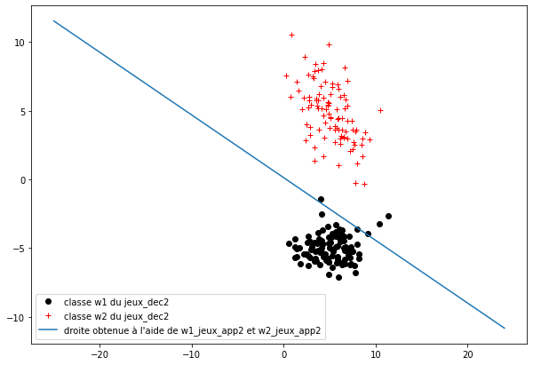

```python
plt.figure(figsize=(10,7))
dataset = 2
OvsO_adapte(w1_app2, w2_app2, w1_test2, w2_test2, dataset, "w1_jeux_app2 et w2_jeux_app2", 1, 2, plt.gca())
```

Autre illustration ... :

```
'le taux de bonne classification est : 28.5 %'
```

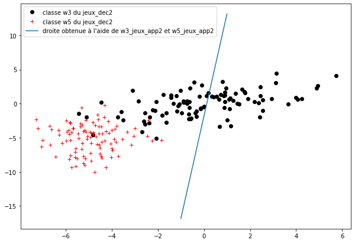

```python
plt.figure(figsize=(10,7))
dataset = 2
OvsO_adapte(w3_app2, w5_app2, w3_test2, w5_test2, dataset, "w3_jeux_app2 et w5_jeux_app2", 3, 5, plt.gca())
```

```
'le taux de bonne classification est : 95.0 %'
```

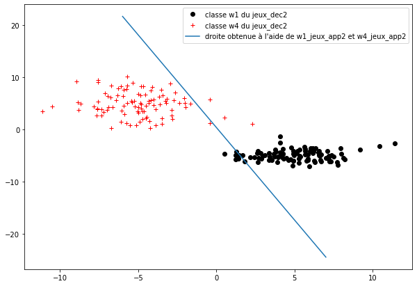

```python
plt.figure(figsize=(10,7))
dataset = 2
OvsO_adapte(w1_app2, w4_app2, w1_test2, w4_test2, dataset, "w1_jeux_app2 et w4_jeux_app2", 1, 4, plt.gca())
```

Et ainsi de suite...on peut donc constater que le dataset 2 n'est pas linéairement séparable.

### Pour TP3_app & TP3_test

```python
df_dec3 = pretraitement("data_tp3_dec.txt")
```

```
<class 'pandas.core.frame.DataFrame'>
RangeIndex: 500 entries, 0 to 499
Data columns (total 3 columns):
 #   Column   Non-Null Count  Dtype
---  ------   --------------  -----
 0   classes  500 non-null    object
 1   X        500 non-null    object
 2   Y        500 non-null    object
dtypes: object(3)
memory usage: 11.8+ KB
```

```python
w1_test3, w2_test3, w3_test3, w4_test3, w5_test3, df_dec3 = getClasses(df_dec3)
```

```
'le taux de bonne classification est : 30.0 %'
```

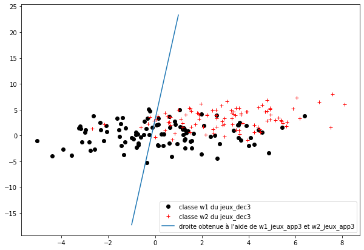

```python
plt.figure(figsize=(10,7))
dataset = 3
OvsO_adapte(w1_app3, w2_app3, w1_test3, w2_test3, dataset, "w1_jeux_app3 et w2_jeux_app3", 1, 2, plt.gca())
```

```
'le taux de bonne classification est : 97.5 %'
```

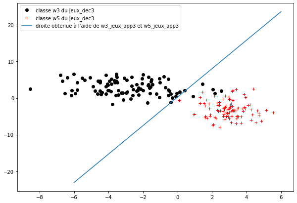

```python
plt.figure(figsize=(10,7))
dataset = 3
OvsO_adapte(w3_app3, w5_app3, w3_test3, w5_test3, dataset, "w3_jeux_app3 et w5_jeux_app3", 3, 5, plt.gca())
```

Le dataset 3 aussi n'est pas linéairement séparable.

# Question 3

### Approche One Versus All 🤓

- Après avoir supprimé des 3 jeux de données la classe centrale (classe ‘e’ ou 5), adapter votre algorithme de décision en cherchant un hyperplan qui sépare une classe de toutes les autres (soit pour 4 classes, 4 hyperplans à déterminer).

```python
def split_data_for_OvsA(df,Classe_i):
    # Si ci = 1, 2, 3 ou 4
    W1 = df[df.classes==Classe_i].iloc[:,0:3] # Classe 1
    W2 = df[df.classes!=Classe_i].iloc[:,0:3] # Classe 2, 3, 4
    W2 = W2[W2.classes!=5].iloc[:,0:3]
    return W1,W2
```

- Evaluer les performances (taux de bonne classification en Top1, matrice de confusion)

```python
def Confusion_Matrix(w1,w,w1_test,w2_test, txt):
    plt.figure()
    plt.ylim((-50,50))
    accuracy = []
    w = [w1,w2,w3,w4]
    for i in range(3):
        accuracy.append(screen_OvsO_adapte2(w1, w[i], w1_test, w2_test, txt, c1, c2, plt.gca()))
    return accuracy
```

- perceptron One versus All

```python
def perceptron_OvA(df, Classe_i, A):
    assert len(A)==df.shape[1]
    W1, W2 = split_data_for_OvsA(df,Classe_i)
    W1T, W2T = Xtransformation(W1, W2)
    W = np.array(pd.concat([W2T,W1T]))
    Vecteur_A = [A]
    #juste pour savoir combien d'itération ont été faites !
    iteration = 0
    check = True
    sizeW1 = len(W1)
    sizeW2 = len(W2)
    taux = 100
    check_error = True
    while(check and check_error):
        check = False
        iteration += 1
        check_error = False
        #print("*************************")
        #print("iteration="+str(iteration))
        for i in range(len(W)):
            if(np.dot(W[i,0:3],A.reshape(-1,1))[0]<=0):
                check = True
                A = np.add(W[i,0:3],A)
                #print(A)
        Vecteur_A.append(A)
        n = len(Vecteur_A)
        new_taux =  classification_accuracy2(np.array(W1),Vecteur_A[len(Vecteur_A)-1],np.array(W2),sizeW1,sizeW2)
        if new_taux != taux:
            check_error = True
        taux = new_taux
    return Vecteur_A, n, iteration
```

```python
A = np.array([0,0,0])
p_app, n, iteration = perceptron_OvA(df_app1, 1, A)
```

```python
n
```

```
3
```

```python
iteration
```

```
2
```

```python
p_app[len(p_app)-1]
```

```
array([ 0.237005,  7.827912, -8.      ])
```

### Fonctions pour réaliser une sépartion linéaire OvsAll sur TP2

```python
def point_coeff_dir2(Classe_i, A, precision):
    pointX = []
    pointY = []
    for i in range(precision[2], precision[1], precision[0]):
        Coefficient_directeur = ((-A[0])* i - A[2]) / A[1]
        if(Classe_i==3):
            pointX.append(i/100)
            pointY.append(Coefficient_directeur/100)
        else :
            pointX.append(i)
            pointY.append(Coefficient_directeur)
    return pointX,pointY
```

```python
def uneSeparation_OvsAll(Classe_i, A, X1, X2, precision, txt, a, b):
    plt.figure(figsize=(15,10))
    pointX, pointY = point_coeff_dir2(Classe_i, A, precision)
    plt.scatter((X1.iloc[:, 1:3]).iloc[:,0], (X1.iloc[:, 1:3]).iloc[:, 1], label= 'classe '+str(a)+'')
    plt.scatter((X2.iloc[:, 1:3]).iloc[:, 0], (X2.iloc[:, 1:3]).iloc[:, 1], label= 'classes '+str(b)+'')
    plt.title(txt)
    plt.legend()
    plt.plot(pointX, pointY)
```

```python
def screenOvsAll(Classe_i, df,txt, a, b):
    A = np.array([0,0,0])
    X1, X2 = split_data_for_OvsA(df,Classe_i)
    p_app, n, iteration = perceptron_OvA(df, Classe_i, A)
    uneSeparation_OvsAll(Classe_i,p_app[len(p_app)-1], X1, X2, [1, 15, -15],txt, a, b)
```

### 1. Visualisation à l'aide des données d'apprentissage 1, des droites séparations linéaires obtenues à l'aide de ces même données

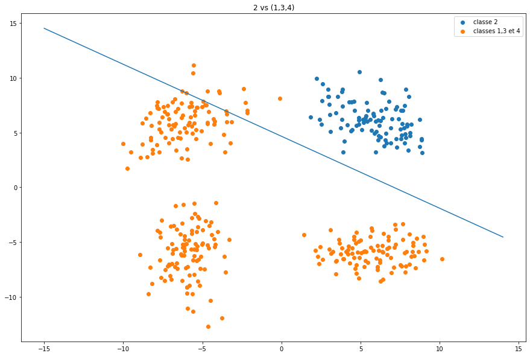

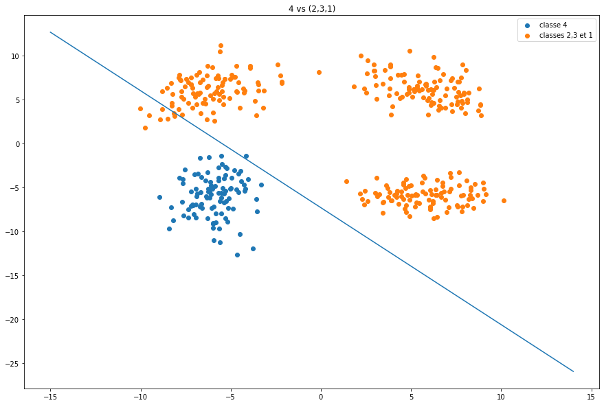

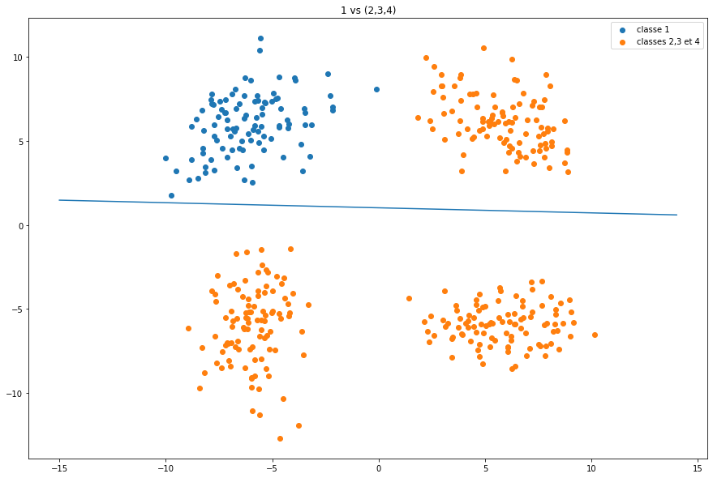

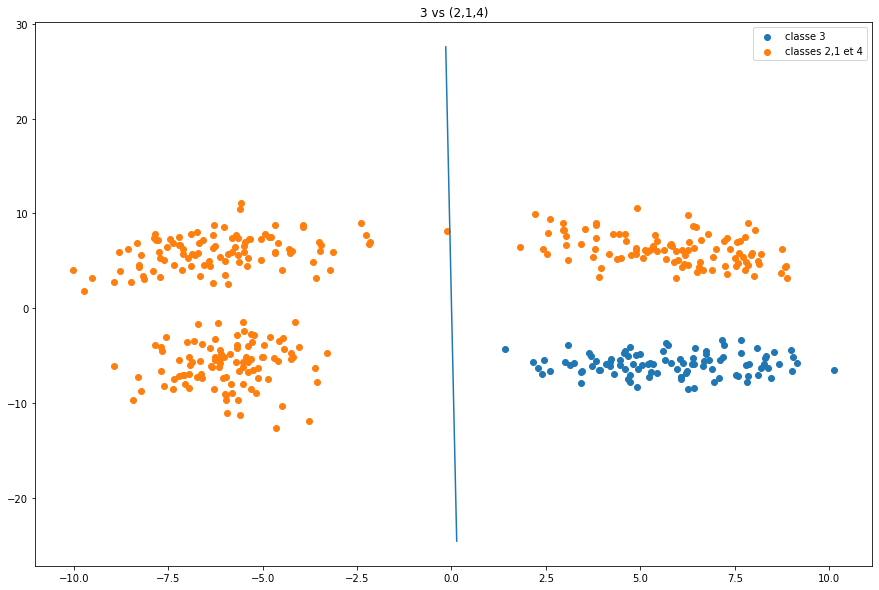

```python
screenOvsAll(2, df_app1, "2 vs (1,3,4)", "2", "1,3 et 4")
screenOvsAll(4, df_app1, "4 vs (2,3,1)", "4", "2,3 et 1")
screenOvsAll(1, df_app1, "1 vs (2,3,4)", "1", "2,3 et 4")
screenOvsAll(3, df_app1, "3 vs (2,1,4)", "3", "2,1 et 4")
```

### 2. Evaluation TOP 1 :On test nos données de décisions sur les droites de séparations linéaires obtenues après apprentissage

```python
def classification_accuracy2(W1,last_a,W2,size1,size2):
    tx = 0
    size_of_data = size1+size2
    for point1 in W1:
        metrique1=equation(last_a,point1)
        if metrique1>0:
            tx = tx + 1
    for point2 in W2:
        metrique2=equation(last_a,point2)
        if metrique2<0:
            tx = tx + 1
    return (tx * 100)/ size_of_data
```

```python
def OvsA_adapte(Classe_i,df_app, df_dec, txt, a, b):
    A = np.array([0,0,0])
    precision=[1, 25, -25]
    X1_dec, X2_dec = split_data_for_OvsA(df_dec,Classe_i)
    p_app, n, iteration = perceptron_OvA(df_app, Classe_i, A)
    uneSeparation_OvsAll(Classe_i,p_app[len(p_app)-1], X1_dec, X2_dec, [1, 15, -15],txt, a, b)
    return "le taux de bonne classification est : "+str(classification_accuracy2(np.array(X1_dec), p_app[len(p_app)-1],np.array(X2_dec),len(X1_dec),len(X2_dec)))+ " %"
```

```
'le taux de bonne classification est : 98.0 %'
```

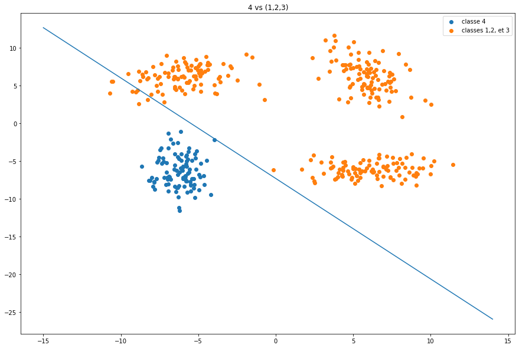

```python
OvsA_adapte(4,df_app1, df_dec1, "4 vs (1,2,3)", "4", "1,2, et 3")
```

# Pas mal on dirait 😉👌 !!

```
'le taux de bonne classification est : 97.0 %'
```

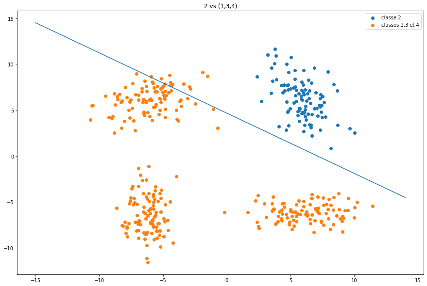

```python
OvsA_adapte(2,df_app1, df_dec1, "2 vs (1,3,4)", "2", "1,3 et 4")
```

```
'le taux de bonne classification est : 75.0 %'
```

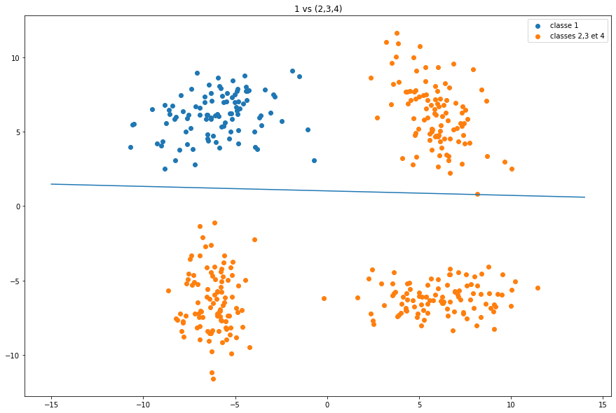

```python
OvsA_adapte(1,df_app1, df_dec1, "1 vs (2,3,4)", "1", "2,3 et 4")
```

```
'le taux de bonne classification est : 74.75 %'
```

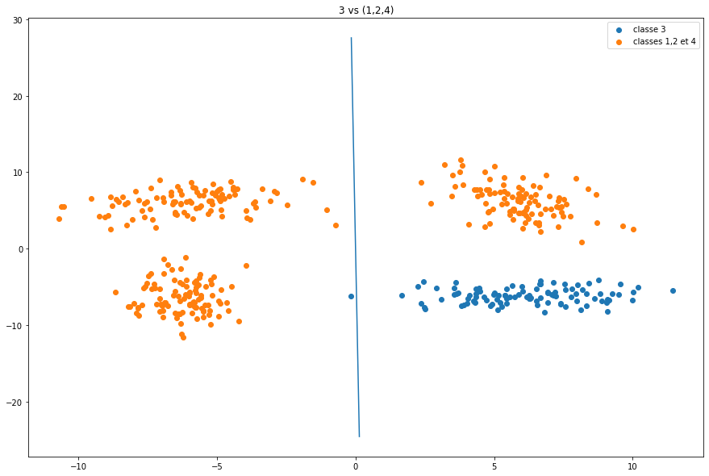

```python
OvsA_adapte(3,df_app1, df_dec1, "3 vs (1,2,4)", "3", "1,2 et 4")
```

### Evaluation avec Matrice de Confusion sur les jeux d'apprentissages et de test 1 en One versus One

```python
def classification_accuracy3(W1,last_a,W2,size1,size2):
    tx = 0
    size_of_data = size1+size2
    for point1 in W1:
        metrique1=equation(last_a,point1)
        if metrique1<0:
            tx = tx + 1
    for point2 in W2:
        metrique2=equation(last_a,point2)
        if metrique2<0:
            tx = tx + 1
    return (tx * 100)/ size_of_data
```

```python
def Confusion_Matrix(df_app, df_dec):
    accuracy = []
    A = np.array([0,0,0])
    Vecteur_A = []
    W = [df_app.iloc[0:100,:],
        df_app.iloc[100:200,:],
        df_app.iloc[200:300,:],
        df_app.iloc[300:400,:],
        df_app.iloc[400:500,:]]
    W_dec = [df_dec.iloc[0:100,:],
        df_dec.iloc[100:200,:],
        df_dec.iloc[200:300,:],
        df_dec.iloc[300:400,:],
        df_dec.iloc[400:500,:]]
    precision=[1, 25, -25]
    check_init = 1
    check = 1 # On check j
    p_app = []
    start = 0
    scores = []
    print("👉 Les A de chaque droites : \n")
    for i in range(start, 5):
        if (i==4):
            break;
        for j in range(start,5):
            if check > i and i!=j and check!=i :
                p_app, n, iteration = perceptron(W[j], W[i], A)
                scores.append(classification_accuracy3(np.array(W_dec[i]), p_app[len(p_app)-1],np.array(W_dec[j]),len(W_dec[i]),len(W_dec[j])))
                Vecteur_A.append(p_app[len(p_app)-1])
                print(p_app[len(p_app)-1])
                check += 1
        check_init +=1
        check = check_init
        start = check - 1
    print("\n👉 Nombre : ",len(Vecteur_A),"\n")
    scores2 = []
    for i in range(5):
        if i!= 2 :
            p_app2, n, iteration = perceptron(W[i], W[i], A)
            print(p_app2[2])
        else :
            p_app, n, iteration = perceptron(W[i], W[i], A)
        scores2.append(classification_accuracy3(np.array(W_dec[i]), p_app[len(p_app)-1],np.array(W_dec[i]),len(W_dec[i]),len(W_dec[i])))
    matrice = np.zeros((5,5))
    for i in range(5):
        for j in range(5):
                if i!=j :
                    matrice[i,j]=scores[i]
                elif i==j :
                    matrice[i,j]=scores2[i]
    print("👇 La matrice de confusion est :\n")
    return matrice
```

## Evaluation :

### ▶️ Dataset app1 et dec1

```python
w1, w2, w3, w4, w5, df_app1 = getClasses(df_app1)
w1, w2, w3, w4, w5, df_dec1 = getClasses(df_dec1)
score1 = Confusion_Matrix(df_app1,df_dec1)
print(score1)
```

```
👉 Les A de chaque droites :

[ 8.        2.167007 17.470169]
[21.        2.310403  1.265219]
[ 11.       -19.172044   1.441982]
[ 5.       -0.870703 -0.152942]
[ 5.       12.179131  0.813008]
[18.        0.139387 -2.721666]
[ 5.       -0.870703 -0.152942]
[  7.         2.274981 -12.276603]
[ 5.       -0.870703 -0.152942]
[ 5.       -0.870703 -0.152942]

👉 Nombre :  10

[ 1.       -6.315382  6.344938]
[2.       3.043789 6.633307]
[ 4.       -5.824326 -8.025893]
[ 5.       -0.870703 -0.152942]
👇 La matrice de confusion est :

[[100.   43.   43.   43.   43. ]
 [ 50.5   0.   50.5  50.5  50.5]
 [ 54.   54.  100.   54.   54. ]
 [ 74.   74.   74.  100.   74. ]
 [ 50.   50.   50.   50.   75. ]]
```

### ▶️ Dataset app2 et dec2

```python
w1, w2, w3, w4, w5, df_app2 = getClasses(df_app2)
w1, w2, w3, w4, w5, df_dec2 = getClasses(df_dec2)
score1 = Confusion_Matrix(df_app2,df_dec2)
print(score1)
```

```
👉 Les A de chaque droites :

[ 4.        8.767356 -1.126612]
[ 6.       -0.400459 -0.738887]
[ 5.        1.40751  -0.502933]
[  6.         4.59722  -10.238909]
[ 6.       -0.400459 -0.738887]
[10.        0.091702  9.748202]
[14.        2.654183 -2.24269 ]
[10.       -5.184548  0.684718]
[ 8.       -1.145801 -3.689177]
[  9.       -11.058208  -0.411328]

👉 Nombre :  10

[ 1.        4.917866 -3.116518]
[2.       2.085519 7.437741]
[ 4.       -3.510356  2.613585]
[ 5.       -4.799005 -7.322054]
👇 La matrice de confusion est :

[[50.   2.   2.   2.   2. ]
 [78.5 50.  78.5 78.5 78.5]
 [95.  95.  50.  95.  95. ]
 [71.  71.  71.  50.  71. ]
 [77.5 77.5 77.5 77.5 50. ]]
```

### ▶️ Dataset app3 et dec3

```python
w1, w2, w3, w4, w5, df_app3 = getClasses(df_app3)
w1, w2, w3, w4, w5, df_dec3 = getClasses(df_dec3)
score1 = Confusion_Matrix(df_app3,df_dec3)
print(score1)
```

```
👉 Les A de chaque droites :

[11.       -0.80104   0.810138]
[ 7.       -0.510939 -0.555732]
[13.        1.629602  0.972068]
[15.        1.546771 -2.440508]
[10.       -3.070954  1.988656]
[8.       0.682186 4.363837]
[ 5.        2.844938 -0.704711]
[ 7.       -6.330737  0.961124]
[16.       -4.109471  1.092245]
[ 9.       -6.289626 -4.718907]

👉 Nombre :  10

[ 7.       -0.344804  1.047975]
[2.       3.17767  2.549837]
[ 4.       -4.538946 -4.589303]
[ 5.        2.844938 -0.704711]
👇 La matrice de confusion est :

[[ 41.   72.   72.   72.   72. ]
 [ 28.   53.   28.   28.   28. ]
 [ 29.5  29.5  11.   29.5  29.5]
 [ 75.5  75.5  75.5  69.   75.5]
 [ 46.5  46.5  46.5  46.5 100. ]]
```

# Question 4 : Analyse et Conclusion

Tout au long de ce travail, on peut s'apercevoir que le perceptron est un algorithme facile à mettre en oeuvre.

Une fois que l'on apprend avec les données d'apprentisages, on peut les mettre de coté et ne se focaliser que sur l'hyper plan qui est la droite de séparation linéaire obtenue à l'aide de ces derniers, laquelle permet de décider sur les données de test.

Nous avons eu à notre disposition 3 Datasets soit 3 jeux de données, le premier dataset nous a donné **des résultats satisfaisants** car, avec ce dernier on a bien pu voir que les données étient linéairement séparables, le deuxième jeux de données pas aussi simple que son précédent, nous a quand même permit d'avoir des résultats **plus au moins passable**, par contre avec le troisième, il était claire que nous étions là face à un jeux de données quasi non linéaire et donc **pour le quel la quête des hyperplans était nécessaire dans un context One versus All, mais n'a pas su dans la mesure du possible, sufir à remplir les conditions des hypothèses de linéarité**.

En plus de l'évaluation en Top1, nous avons aussi essayer de ressortir une matrice de confusion avant d'aboutir à cette conclusion.

Par conséquent, nous osons dire que des jeux de données 1 à 3 nous partons du plus linéaire, au moins linéaire.

# 2) Travail Pratique 2 : les arbres de décisions

## 1. Préparation de l’environnement

```python
!pip install graphviz
```

```python
!pip install pydotplus
```

```python
from sklearn.datasets import load_iris
import graphviz
from sklearn.model_selection import train_test_split
from sklearn import tree
from sklearn.model_selection import cross_val_score
import numpy as np
from sklearn.neighbors import KNeighborsClassifier
import pandas as pd
from sklearn.naive_bayes import GaussianNB
import seaborn as sn
import matplotlib.pyplot as plt
from sklearn.datasets import make_moons
```

## 2. Construire et visualiser un arbre de décision

On récupère le jeu de données des iris pour comprendre les arbres de décisions, il s'agit d'un jeu de données célèbre qui comporte la longueur et la largeur des sépales et des pétales en cm, de 150 fleurs d'iris de trois espèces différentes qui sont : Setosa, Versicolor et Virginica.

L'objevctif de ce TP est simple : développer un programme capable de reconnaitre une espèce parmi plusieurs de la famille des Iris. L’algorithme utilisera alors les 4 features pour effectuer son calcul :

```
• 𝒙𝟏 : La longueur du pétale
• 𝒙𝟐 : La largeur du pétale
• 𝒙𝟑 : La longueur du sépale
• 𝒙𝟒 : La largeur du sépale
```

[figure not shown]

```python
iris = load_iris()
X = iris.data # Les features
y = iris.target # Les targets
colormap=np.array(['Red','black','blue'])
plt.scatter(X[:,3], X[:,1], c = colormap[y])
plt.xlabel("Largeur de pétale")
plt.ylabel("Longueur de pétale")
plt.show()
```

## 2.1. L'algorithme Decision Tree

> On commence d'abord par appliquer une politique 70-30 pour générer les données d'apprentissages (ou d'entrainement) et, les donnes de tests (ou de décision) avec la fonction **train_test_split**

```python
X_train, X_test, y_train, y_test = train_test_split(X, y, test_size=0.30, random_state=42)
```

> Utilisez la fonction **DecisionTreeClassifier** pour construire un arbre de décision sur cette base. Vous utiliserez les paramètres par défaut de l’algorithme.

```python
# création du modèle
modelTree = tree.DecisionTreeClassifier()

# entraînement du modèle
modelTree.fit(X_train,y_train)
```

```
DecisionTreeClassifier()
```

### récupération des entêtes

```python
classes = iris.target_names
features = iris.feature_names
```

```python
classes
```

```
array(['setosa', 'versicolor', 'virginica'], dtype='<U10')
```

```python
features
```

```
['sepal length (cm)',
 'sepal width (cm)',
 'petal length (cm)',
 'petal width (cm)']
```

### visualisation

> Pour visualiser le résultat de cet apprentissage, vous pouvez exporter la structure de l’arbre obtenu au format DOT de Graphviz:
- Utilisez la fonction export_graphviz pour exporter la structure de l’arbre dans un fichier .dot.
- Chargez le contenu du fichier obtenu dans un visualiseur en ligne.
- Si vous avez installé les packages python pour Graphviz, vous pouvez visualiser et/ou exporter directement le graphe dans le script python

## Executez cette cellule pour visualiser le graphe.

```python
# exportation de la structure de l'arbre dans un fichier .dot
dotFile = open("file1.dot", "w")

# Viusaliseur en ligne
tree.export_graphviz(modelTree, out_file=dotFile,
                    feature_names=features,
                    class_names=classes,
                    filled=True, rounded=True,
                    special_characters=True)
dotFile.close()

# Visualisation
dot_data = tree.export_graphviz(modelTree, out_file=None,
                        feature_names=features,
                        class_names=classes,
                        filled=True, rounded=True,
                        special_characters=True)
graph = graphviz.Source(dot_data)
graph
```

[figure not shown]

##### Commentaire :

Les noeuds terminaux d'un arbre de décision représentent des classes. Par exemple, si nous voulons obtenir la classe setosa, il faut que petal length soit inférieur ou égale à 2.45

# 3. Comparaison de classifiers

## 3.1) Comparaison sans validation croisée

Cet exercice vise à comparer les performances d’un arbre de décision à celles des classifieurs Gaussian Naive Bayes et K-Plus Proches Voisins:

- Découper la base Iris en deux sous-ensembles: un pour l’apprentissage et l’autre pour évaluer les performances en test. Scikit-learn propose des fonctions pour faire cela
- Lancez l’apprentissage d’un arbre de décision sur le sous-ensemble d’apprentissage.
- Lancez l’apprentissage d’un GaussianNB7 et d’un KNeighborsClassifier8 sur le même sous-ensemble d’apprentissage.
- Pour chacun de ces classifieurs, calculez le taux de bonne classification et affichez le résultat, à l’aide de la fonction score.

```python
# dataset iris

# Notons que le modèle de l'arbre de décision a déjà été entrainé

modelNB = GaussianNB()
modelKNN = KNeighborsClassifier(n_neighbors=3)
```

```python
# Entraînement (apprentissage) des 2 modèles

modelNB = modelNB.fit(X_train, y_train)
modelKNN = modelKNN.fit(X_train, y_train)
```

```python
# Score

score_summary = []

scoreTree=modelTree.score(X_test, y_test)
scoreNB=modelNB.score(X_test, y_test)
scoreKNN=modelKNN.score(X_test, y_test)

score_summary.append(dict(model="Decision tree",accuracy=scoreTree))
score_summary.append(dict(model="Naives Bayes",accuracy=scoreNB))
score_summary.append(dict(model="K-Neighbors",accuracy=scoreKNN))
```

```python
df_sum = pd.DataFrame(score_summary)
```

```python
df_sum
```

|  | model | accuracy |
| --- | --- | --- |
| 0 | Decision tree | 1.000000 |
| 1 | Naives Bayes | 0.977778 |
| 2 | K-Neighbors | 1.000000 |

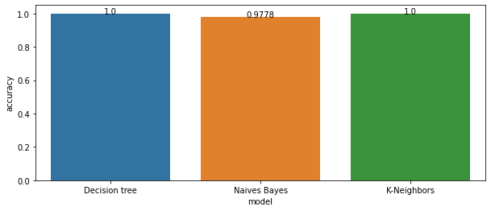

```python
figure = plt.figure(figsize=(10,4))
ax = sn.barplot(y='accuracy', x='model', data=df_sum)
# j'ajoute les valeurs
for index, row in df_sum.iterrows():
    ax.text(row.name,row.accuracy, round(row.accuracy,4), color='black', ha="center")

plt.show()
```

## 3.2) Comparaison avec validation croisée

Pour obtenir un indicateur de performance plus fiable, vous allez recommencer en utilisant une validation croisée:

- Lancez une procédure de validation croisée à 5 folds pour calculer un taux de bonne classification moyen et un écart-type correspondant. Scikit-learn propose des fonctions pour faire cela
- Pour chaque classifieur, affichez le résultat sous la forme: Accuracy: mean (+/- std) où mean et std sont à remplacer par les valeurs obtenues

```python
def cvComparaison(Model, X, y, kfolds):
    scoreCV = cross_val_score(Model,X,y,cv=kfolds)
    mean = np.mean(scoreCV)
    std = np.std(scoreCV)
    return mean, std
```

```python
def printResult(model, m,s):
    print(model+" Accuracy: "+str(m)+" (+/- "+str(s)+")")
```

```python
# Decision tree with CV

TreeMean, TreeStd = cvComparaison(tree.DecisionTreeClassifier(), X, y, 5)
```

```python
# Gaussian NB with CV

NbMean, NbStd = cvComparaison(GaussianNB(), X, y, 5)
```

```python
# KNN with CV

KnnMean, KnnStd = cvComparaison(KNeighborsClassifier(), X, y, 5)
```

```python
printResult("Tree -> ",TreeMean,TreeStd)
printResult("NB -> ",NbMean,NbStd)
printResult("KNN -> ",KnnMean,KnnStd)
```

```
Tree ->  Accuracy: 0.9666666666666668 (+/- 0.036514837167011066)
NB ->  Accuracy: 0.9533333333333334 (+/- 0.02666666666666666)
KNN ->  Accuracy: 0.9733333333333334 (+/- 0.02494438257849294)
```

#### Commentaire :

Avec la validation croisée, on peut bien afficrmer que, on obtient des score raisonnable sur nos 3 classifieurs. Par exemple, il s'agit bient du KNC qui se distingue des autres.

## 3.3) Reproduisez cette comparaison sur plusieurs bases de données jouets proposées par Scikit-Learn, analysez les résultats et donnez vos conclusions : ici, nous allons le faire sur 2 bases de données :

```python
from sklearn.datasets import load_wine
```

```python
wines = load_wine()

X_wines = wines.data
y_wines = wines.target

print('dimension de X :', X_wines.shape)
print("")
print("les différentes valeurs de nos features : \n",X_wines)
print("")
print('on veut prédire un cultivateur (0, 1 ou 2) par vin : ',y_wines)
```

```
dimension de X : (178, 13)

les différentes valeurs de nos features :
 [[1.423e+01 1.710e+00 2.430e+00 ... 1.040e+00 3.920e+00 1.065e+03]
 [1.320e+01 1.780e+00 2.140e+00 ... 1.050e+00 3.400e+00 1.050e+03]
 [1.316e+01 2.360e+00 2.670e+00 ... 1.030e+00 3.170e+00 1.185e+03]
 ...
 [1.327e+01 4.280e+00 2.260e+00 ... 5.900e-01 1.560e+00 8.350e+02]
 [1.317e+01 2.590e+00 2.370e+00 ... 6.000e-01 1.620e+00 8.400e+02]
 [1.413e+01 4.100e+00 2.740e+00 ... 6.100e-01 1.600e+00 5.600e+02]]

on veut prédire un cultivateur (0, 1 ou 2) par vin :  [0 0 0 0 0 0 0 0 0 0 0 0 0 0 0 0 0 0 0 0 0 0 0 0 0 0 0 0 0 0 0 0 0 0 0 0 0
 0 0 0 0 0 0 0 0 0 0 0 0 0 0 0 0 0 0 0 0 0 0 1 1 1 1 1 1 1 1 1 1 1 1 1 1 1
 1 1 1 1 1 1 1 1 1 1 1 1 1 1 1 1 1 1 1 1 1 1 1 1 1 1 1 1 1 1 1 1 1 1 1 1 1
 1 1 1 1 1 1 1 1 1 1 1 1 1 1 1 1 1 1 1 2 2 2 2 2 2 2 2 2 2 2 2 2 2 2 2 2 2
 2 2 2 2 2 2 2 2 2 2 2 2 2 2 2 2 2 2 2 2 2 2 2 2 2 2 2 2 2 2]
```

```python
# Split data
X_wines_train, X_wines_test, y_wines_train, y_wines_test = train_test_split(X_wines, y_wines, test_size=0.30, random_state=42)

# création du modèle
modelTreeWines = tree.DecisionTreeClassifier()

# entraînement du modèle
modelTreeWines.fit(X_wines_train,y_wines_train)

# get entêtes
classes_wines = wines.target_names
features_wines = wines.feature_names
```

```python
print('les cultivateurs (classes) : \n\n',classes_wines)
print("")
print('les features (caractéristiques  chimiques des vins) : \n\n',features_wines)
```

```
les cultivateurs (classes) :

 ['class_0' 'class_1' 'class_2']

les features (caractéristiques  chimiques des vins) :

 ['alcohol', 'malic_acid', 'ash', 'alcalinity_of_ash', 'magnesium', 'total_phenols', 'flavanoids', 'nonflavanoid_phenols', 'proanthocyanins', 'color_intensity', 'hue', 'od280/od315_of_diluted_wines', 'proline']
```

## Exécutez cette cellule afin de visualiser le graphe

```python
# exportation de la structure de l'arbre dans un fichier .dot
dotFile_wines = open("file2.dot", "w")

# Viusaliseur en ligne
tree.export_graphviz(modelTreeWines, out_file=dotFile_wines,
                    feature_names=features_wines,
                    class_names=classes_wines,
                    filled=True, rounded=True,
                    special_characters=True)
dotFile_wines.close()

# Visualisation
dot_wine = tree.export_graphviz(modelTreeWines, out_file=None,
                        feature_names=features_wines,
                        class_names=classes_wines,
                        filled=True, rounded=True,
                        special_characters=True)
graph = graphviz.Source(dot_wine)
graph
```

[figure not shown]

```python
# Decision tree with CV

TreeMean_wines, TreeStd_wines = cvComparaison(tree.DecisionTreeClassifier(), X_wines, y_wines, 5)

# Gaussian NB with CV

NbMean_wines, NbStd_wines = cvComparaison(GaussianNB(), X_wines, y_wines, 5)

# KNN with CV

KnnMean_wines, KnnStd_wines = cvComparaison(KNeighborsClassifier(), X_wines, y_wines, 5)

printResult("Tree ->",TreeMean_wines,TreeStd_wines)
printResult("NB ->",NbMean_wines,NbStd_wines)
printResult("KNN ->",KnnMean_wines,KnnStd_wines)
```

```
Tree -> Accuracy: 0.8763492063492062 (+/- 0.0627705030601298)
NB -> Accuracy: 0.9663492063492063 (+/- 0.02113317858457236)
KNN -> Accuracy: 0.6912698412698413 (+/- 0.04877951071049148)
```

#### Commentaire :

Avec le dataset sur les vins, on peut constater que GaussianNB est efficace, masi ce pendant, on ne perd pas de vue que tout est question de la manière dont les données sont aléatoirment obtenu au niveau du split.

**3.3.2) Pour finir notre exploration de cet algorithme sur différentes bases de données qu'offre sklearn, on va s'intéresse à présent aux dignostics sur le cancer du sein dans le Wisconsin, l'objectif serait de dire si pour chaque sujet, il s'agit d'un cas malin ou bénigne. Ce jeu de donnés comporte 569 observations, dont 30 features**

```python
from sklearn.datasets import load_breast_cancer
```

```python
# on charge et on renvoie l'ensemble de données sur le cancer du sein au Wisconsin
cancer = load_breast_cancer()

X_cancer = cancer.data
y_cancer = cancer.target

print('dimension de X :\n', X_cancer.shape)
print("")
print("les différentes valeurs de nos features : \n",X_cancer)
print("")
print('on veut prédire pour chaque sujet une situation (maligne ou Bénigne) : \n',y_cancer)
```

```
dimension de X :
 (569, 30)

les différentes valeurs de nos features :
 [[1.799e+01 1.038e+01 1.228e+02 ... 2.654e-01 4.601e-01 1.189e-01]
 [2.057e+01 1.777e+01 1.329e+02 ... 1.860e-01 2.750e-01 8.902e-02]
 [1.969e+01 2.125e+01 1.300e+02 ... 2.430e-01 3.613e-01 8.758e-02]
 ...
 [1.660e+01 2.808e+01 1.083e+02 ... 1.418e-01 2.218e-01 7.820e-02]
 [2.060e+01 2.933e+01 1.401e+02 ... 2.650e-01 4.087e-01 1.240e-01]
 [7.760e+00 2.454e+01 4.792e+01 ... 0.000e+00 2.871e-01 7.039e-02]]

on veut prédire pour chaque sujet une situation (maligne ou Bénigne) :
 [0 0 0 0 0 0 0 0 0 0 0 0 0 0 0 0 0 0 0 1 1 1 0 0 0 0 0 0 0 0 0 0 0 0 0 0 0
 1 0 0 0 0 0 0 0 0 1 0 1 1 1 1 1 0 0 1 0 0 1 1 1 1 0 1 0 0 1 1 1 1 0 1 0 0
 1 0 1 0 0 1 1 1 0 0 1 0 0 0 1 1 1 0 1 1 0 0 1 1 1 0 0 1 1 1 1 0 1 1 0 1 1
 1 1 1 1 1 1 0 0 0 1 0 0 1 1 1 0 0 1 0 1 0 0 1 0 0 1 1 0 1 1 0 1 1 1 1 0 1
 1 1 1 1 1 1 1 1 0 1 1 1 1 0 0 1 0 1 1 0 0 1 1 0 0 1 1 1 1 0 1 1 0 0 0 1 0
 1 0 1 1 1 0 1 1 0 0 1 0 0 0 0 1 0 0 0 1 0 1 0 1 1 0 1 0 0 0 0 1 1 0 0 1 1
 1 0 1 1 1 1 1 0 0 1 1 0 1 1 0 0 1 0 1 1 1 1 0 1 1 1 1 1 0 1 0 0 0 0 0 0 0
 0 0 0 0 0 0 0 1 1 1 1 1 1 0 1 0 1 1 0 1 1 0 1 0 0 1 1 1 1 1 1 1 1 1 1 1 1
 1 0 1 1 0 1 0 1 1 1 1 1 1 1 1 1 1 1 1 1 1 0 1 1 1 0 1 0 1 1 1 1 0 0 0 1 1
 1 1 0 1 0 1 0 1 1 1 0 1 1 1 1 1 1 1 0 0 0 1 1 1 1 1 1 1 1 1 1 1 0 0 1 0 0
 0 1 0 0 1 1 1 1 1 0 1 1 1 1 1 0 1 1 1 0 1 1 0 0 1 1 1 1 1 1 0 1 1 1 1 1 1
 1 0 1 1 1 1 1 0 1 1 0 1 1 1 1 1 1 1 1 1 1 1 1 0 1 0 0 1 0 1 1 1 1 1 0 1 1
 0 1 0 1 1 0 1 0 1 1 1 1 1 1 1 1 0 0 1 1 1 1 1 1 0 1 1 1 1 1 1 1 1 1 1 0 1
 1 1 1 1 1 1 0 1 0 1 1 0 1 1 1 1 1 0 0 1 0 1 0 1 1 1 1 1 0 1 1 0 1 0 1 0 0
 1 1 1 0 1 1 1 1 1 1 1 1 1 1 1 0 1 0 0 1 1 1 1 1 1 1 1 1 1 1 1 1 1 1 1 1 1
 1 1 1 1 1 1 1 0 0 0 0 0 0 1]
```

```python
# Split data
X_cancer_train, X_cancer_test, y_cancer_train, y_cancer_test = train_test_split(X_cancer, y_cancer, test_size=0.30, random_state=42)

# création du modèle
modelTreeCancer = tree.DecisionTreeClassifier()

# entraînement du modèle
modelTreeCancer.fit(X_cancer_train,y_cancer_train)

# get entêtes
classes_cancer = cancer.target_names
features_cancer = cancer.feature_names
```

```python
print('les niveau de la maladie (classes) : \n',classes_cancer)
print("")
print('les features (caractéristiques de chaque sujet par rapport à leur situation respective) : \n',features_cancer)
```

```
les niveau de la maladie (classes) :
 ['malignant' 'benign']

les features (caractéristiques de chaque sujet par rapport à leur situation respective) :
 ['mean radius' 'mean texture' 'mean perimeter' 'mean area'
 'mean smoothness' 'mean compactness' 'mean concavity'
 'mean concave points' 'mean symmetry' 'mean fractal dimension'
 'radius error' 'texture error' 'perimeter error' 'area error'
 'smoothness error' 'compactness error' 'concavity error'
 'concave points error' 'symmetry error' 'fractal dimension error'
 'worst radius' 'worst texture' 'worst perimeter' 'worst area'
 'worst smoothness' 'worst compactness' 'worst concavity'
 'worst concave points' 'worst symmetry' 'worst fractal dimension']
```

## Exécutez cette cellule afin de visualiser le graphe

```python
# exportation de la structure de l'arbre dans un fichier .dot
dotFile_cancer = open("file3.dot", "w")

# Viusaliseur en ligne
tree.export_graphviz(modelTreeCancer, out_file=dotFile_cancer,
                    feature_names=features_cancer,
                    class_names=classes_cancer,
                    filled=True, rounded=True,
                    special_characters=True)
dotFile_cancer.close()

# Visualisation
dot_wine = tree.export_graphviz(modelTreeCancer, out_file=None,
                        feature_names=features_cancer,
                        class_names=classes_cancer,
                        filled=True, rounded=True,
                        special_characters=True)
graph = graphviz.Source(dot_wine)
graph
```

[figure not shown]

```python
# Decision tree with CV

TreeMean_cancer, TreeStd_cancer = cvComparaison(tree.DecisionTreeClassifier(), X_cancer, y_cancer, 5)

# Gaussian NB with CV

NbMean_cancer, NbStd_cancer = cvComparaison(GaussianNB(), X_cancer, y_cancer, 5)

# KNN with CV

KnnMean_cancer, KnnStd_cancer = cvComparaison(KNeighborsClassifier(), X_cancer, y_cancer, 5)

printResult("Tree ->",TreeMean_cancer,TreeStd_cancer)
printResult("NB ->",NbMean_cancer,NbStd_cancer)
printResult("KNN ->",KnnMean_cancer,KnnStd_cancer)
```

```
Tree -> Accuracy: 0.9173730787144854 (+/- 0.01981721851462547)
NB -> Accuracy: 0.9385188635305075 (+/- 0.014585994424363306)
KNN -> Accuracy: 0.9279459711224964 (+/- 0.02176276406544814)
```

#### Commentaire :

On peut remarquer que pour le dataset sur le cancer, là encore GaussianNB se distingue positivement des autres.

## 4) Visualiser les frontières de décision

Sur un problème de classification en deux dimensions, on peut facilement visualiser les frontières de décision d’un arbre de décision et analyser comment elles évoluent en fonction de certains paramètres d’apprentissage.

- Générer une base de données synthétique en deux dimensions avec la fonction make_moon de Scikit-learn11. Cette base sera composée de 2 classes, 500 instances, et un taux de bruit de 0.2.

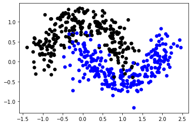

```python
dataX, dataY = make_moons(500, noise = 0.2)
colormap=np.array(['Black','Blue'])
plt.scatter(dataX[:,0], dataX[:,1],color=colormap[dataY])
```

- Lancez l’apprentissage d’un arbre de décision, d’un GaussianNB et d’un KNeighborsClassifier sur cette base, comme à l’exercice précédent.

```python
modelArbre = tree.DecisionTreeClassifier()
modelNaives = GaussianNB()
modelKNC = KNeighborsClassifier()
```

```python
X_app, X_dec, y_app, y_dec = train_test_split(dataX, dataY, test_size=0.30, random_state=42)
```

```python
modelArbre = modelArbre.fit(X_app,y_app)
modelNaives = modelNaives.fit(X_app,y_app)
modelKNC = modelKNC.fit(X_app,y_app)
```

- Créez une fonction python plot_decision_frontiers qui prend en paramètre un classifieur, sa base d’apprentissage et une figure dans laquelle seront dessinés les points (2D) de la base d’apprentissage et les frontières de décision du classifieur.

Cette fonction procédera en plusieurs étapes:

1. Générer une grille de points 2D: {(i, j)} pour i = $x^{(1)}_{min}...x^{(1)}_{max} et j = x^{(2)}_{min}...x^{(2)}_{max}$ Pour cela, utilisez la fonction **meshgrid** de NumPy.
2. Rassembler les prédictions de l’arbre pour chacun des points de cette grille. Les fonctions **ravel**, **c_** et reshape de NumPy pourront vous être utiles.
3. Afficher les points de la base d’apprentissage avec la fonction **scatter** de Matplotlib.
4. Afficher les frontières de décisions en utilisant la fonction **contourf** de Matplotlib.

```python
def plot_decision_frontiers(Model, X, y, check, fig):

    if(check==False):
        txt="tree1-Gini"
    elif(check==True):
        txt="tree2-Entropy"
    else:
        txt=check

    # Meshgrid

    h = .2
    colors = "bry"

    x_min, x_max = X[:, 0].min() - 1, X[:, 0].max() + 1
    y_min, y_max = X[:, 1].min() - 1, X[:, 1].max() + 1
    xx, yy = np.meshgrid(np.arange(x_min, x_max, h),np.arange(y_min, y_max, h))

    Z = Model.predict(np.c_[xx.ravel(), yy.ravel()])
    Z = Z.reshape(xx.shape)

    fig.contourf(xx, yy, Z, cmap=plt.cm.Paired)
    fig.set_title(txt)
    fig.axis('tight')

    for i, color in zip(Model.classes_, colors):
        idx = np.where(y == i)
        fig.scatter(X[idx, 0], X[idx, 1], c=color,cmap=plt.cm.Paired, edgecolor='black', s=20)
```

- Créez une figure contenant 3 sous-figures avec la fonction subplots de Matplotlib.
- Appelez la fonction plot_decision_frontiers pour chacun des trois classifieurs et chacune des 3 sous-figures.

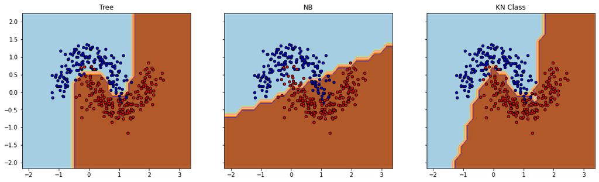

```python
fig, ax = plt.subplots(1, 3, figsize=(18,5), sharex=True, sharey=True)

plot_decision_frontiers(modelArbre, X_app, y_app, "Tree", ax[0])
plot_decision_frontiers(modelNaives, X_app, y_app, "NB", ax[1])
plot_decision_frontiers(modelKNC, X_app, y_app, "KN Class", ax[2])
```

#### Commentaire :

Dans cette première visualisation, on remarque qu'avec nos données d'apprentissages, KNC se comporte correctement.

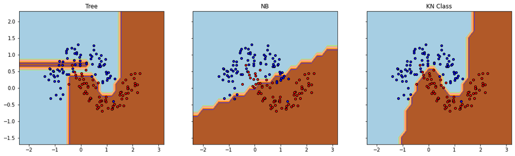

```python
fig, ax = plt.subplots(1, 3, figsize=(18,5), sharex=True, sharey=True)
# dataX, dataY
# X_dec,y_dec
# X_app, y_app
plot_decision_frontiers(modelArbre, X_dec,y_dec, "Tree", ax[0])
plot_decision_frontiers(modelNaives, X_dec,y_dec, "NB", ax[1])
plot_decision_frontiers(modelKNC, X_dec,y_dec, "KN Class", ax[2])
```

#### Commentaire :

avec des données de tests, on parvient aussi à avoir des résulats satisfaisants, avec un Kppv-C et, un Arbre de Décision, ces derniers classifient donc bien les points. Cependant, alors qu'ua niveau de Decision Tree, l'arbre sur-apprends, GaussianNB classe mal les points.

## 5) Étude de paramètres

L’objectif est d’analyser l’influence de quelques paramètres sur les performances d’un arbre de décision. Dans un premier temps, analysez l’effet du critère de partitionnement:

- Générez une nouvelle base avec make_moon, avec 1000 données et un taux de bruits de 0.3.

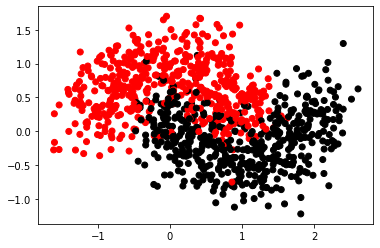

```python
dataX2, dataY2 = make_moons(1000, noise = 0.3)
colormap=np.array(['Red','Black'])
plt.scatter(dataX2[:,0], dataX2[:,1],color=colormap[dataY2])
```

- Lancez l’apprentissage de deux arbres de décision sur cette base: l’un avec le critère de partitionnement Gini, l’autre avec Entropy.

```python
# En apprentissage : l'entropie est nulle lorsque toutes les observations appartiennent à une classe

modelTree1 = tree.DecisionTreeClassifier(criterion="gini")
modelTree2 = tree.DecisionTreeClassifier(criterion="entropy")
```

```python
X_app_1, X_dec_2, y_app_1, y_dec_2 = train_test_split(dataX2, dataY2, test_size=0.30, random_state=42)

modelTree1 = modelTree1.fit(X_app_1,y_app_1)

modelTree2 = modelTree2.fit(X_app_1,y_app_1)
```

- Visualisez les frontières de décision des deux classifieurs ainsi obtenus en utilisant la fonction définie à l’exercice précédent.

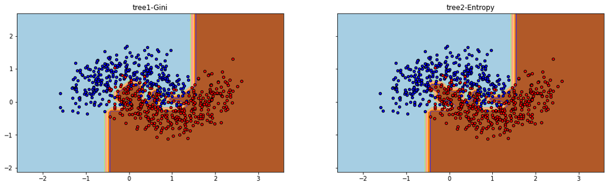

```python
fig, ax = plt.subplots(1, 2, figsize=(18,5), sharex=True, sharey=True)

plot_decision_frontiers(modelTree1, X_app_1,y_app_1, False, ax[0])
plot_decision_frontiers(modelTree2, X_app_1,y_app_1, True, ax[1])
```

#### Commentaire :

Quoi que imparfait, alors qu'au moment de l'apprentissage un arbre de décision avec Gini semble bien classer les points, l'entropy paraît moins performant, ainsi, on va privilégier la discrimination des données selon l'impureté de Gini.

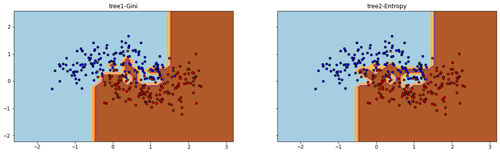

```python
fig, ax = plt.subplots(1, 2, figsize=(18,5), sharex=True, sharey=True)

plot_decision_frontiers(modelTree1, X_dec_2,y_dec_2, False, ax[0])
plot_decision_frontiers(modelTree2, X_dec_2,y_dec_2, True, ax[1])
```

#### Commentaire :

Grosso modo, au moment des tets, on parvient à mieux généraliser avec Gini.

- Estimez également les performances de ces deux algorithmes d’apprentissage avec une procédure de validation croisée.

```python
# Decision tree with CV and gini

TreeMean_Gini, TreeStd_Gini = cvComparaison(tree.DecisionTreeClassifier(), dataX2, dataY2, 5)

# Gaussian NB with CV and entropy

TreeMean_Entropy, TreeStd_Entropy = cvComparaison(tree.DecisionTreeClassifier(), dataX2, dataY2, 5)

printResult("Tree.Gini ->",TreeMean_Gini,TreeStd_Gini)
printResult("Tree.Entropy ->",TreeMean_Entropy,TreeStd_Entropy)
```

```
Tree.Gini -> Accuracy: 0.8899999999999999 (+/- 0.008366600265340762)
Tree.Entropy -> Accuracy: 0.884 (+/- 0.009695359714832668)
```

- Analysez les résultats et donnez vos conclusions.

#### Commentaire :

Dans un deuxième temps, vous allez créer une expérience pour visualiser l’évolution de performances en fonction des valeurs de deux paramètres:

- la profondeur maximum de l’arbre de décision
- le nombre minimum de données par feuille

Pour cela:

- Faites varier les valeurs de chaque paramètre (séparément):

  ```
    - Profondeur maximum: de 1 à 30
    - Nombre minimum de données par feuille (en pourcentage): de 1% à 50%
  ```

- Pour chaque valeur, testez l’apprentissage d’un arbre via une procédure de validation croisée et mémoriser le taux moyen de bonne classification dans un tableau.
- Tracez la courbe de l’évolution du taux moyen de bonne classification en fonction des valeurs de paramètre testées.
- Analysez les résultats et donnez vos conclusions.

```python
X, y = make_moons(10000, noise = 0.3)
```

```python
profondeur = []
tauxGiniMoyen = []
tauxEntropieMoyen = []
```

```python
for i in range(1, 30, 1):
    profondeur.append(i)
    tauxGiniMoyen.append(cvComparaison(tree.DecisionTreeClassifier(max_depth=i, criterion="gini"), X, y, 5)[0])
    tauxEntropieMoyen.append(cvComparaison(tree.DecisionTreeClassifier(max_depth=i, criterion="entropy"), X, y, 5)[0])
```

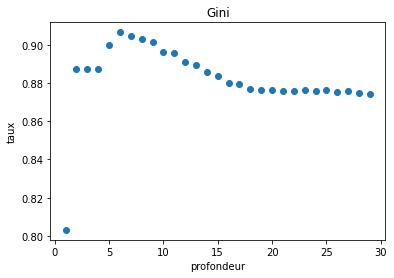

```python
plt.scatter(profondeur, tauxGiniMoyen)
plt.title("Gini")
plt.xlabel("profondeur")
plt.ylabel("taux")
```

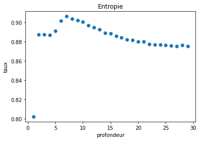

```python
plt.scatter(profondeur, tauxEntropieMoyen)
plt.title("Entropie")
plt.xlabel("profondeur")
plt.ylabel("taux")
```

#### Commentaire :

Autant un arbre est profond, autant il ets complexe, et donc, Gini présente un critère de performance meilleur que Entropie. Nous l'aurons compris, dans le cas contraire, autant un abre est moins profond, autant l'entrpoie est moins meilleur que Gini.

```python
profondeur = []
tauxGiniMoyen = []
tauxEntropieMoyen = []
```

```python
for i in range(1, 50, 1):
    profondeur.append(i)
    tauxGiniMoyen.append(cvComparaison(tree.DecisionTreeClassifier(criterion="gini", min_samples_leaf=i), X, y, 5)[0])
    tauxEntropieMoyen.append(cvComparaison(tree.DecisionTreeClassifier(criterion="entropy", min_samples_leaf=i), X, y, 5)[0])
```

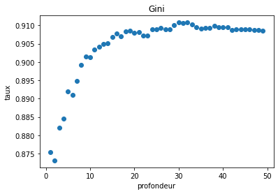

```python
plt.scatter(profondeur, tauxGiniMoyen)
plt.title("Gini")
plt.xlabel("profondeur")
plt.ylabel("taux")
```

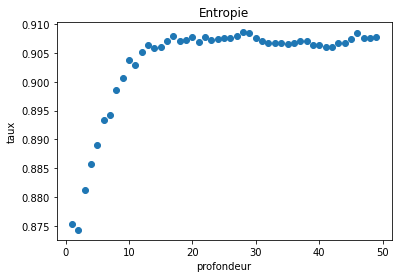

```python
plt.scatter(profondeur, tauxEntropieMoyen)
plt.title("Entropie")
plt.xlabel("profondeur")
plt.ylabel("taux")
```

#### Commentaire :

Gini est performant pour les arbres avec des feuilles aux nombreuses informations, alors que l'Entropie est préférable lorsqu'il y 'en a moins.

# Conclusion sur Decision Tree

efficace certe, on conxtate cependant que les arbres de décisions sur apprennent un peu trop, ce qui nous pousse à dire qu'on devrait alors se permettre d'accepter quelques erreurs sinon ce dernier rencontrera des difficultés de généralisation lorsqu'il faudra décider ou évaluer face à des donénes de tests.

# 3) Travail Pratique 3 : Les machines à vecteurs de support type-SVC pour Support Vector Classification et LinearSVC.

A propos

Dans ce travail, nous allons principalement nous focaliser sur l'algorithme SVM :

nous allons ensuite déterminer pour chacun des cas précédents que nous allons traiter et des différents noyaux que nous allons appliquer :

- Le **accuracy_score** qui est le taux de bonne performance, c'est à dire chercher le taux de bonne classification

Ensuite on va se permettre de trouver :

- le **precision_score** pour dire si le modèle de prédiction est précis
- il y aura le **recall_score** qui est un rappel des cas réel trouvé!
- Il s'en suivra du **f1_score** qui est fonction de la **précision** et du **rappel**, car elle les combine on dit que si ce denrier est petit alors, c'est à dire que la précision

  f1_score = 2 *$ \frac{precision* rappel}{precision+rappel} $

et, est constituée d'une petite précision et d'un petit rappel (inversement pour le cas grand).

Et enfin, au bout du compte, un peu comme dans la pluspart des articles scientifiques sur les data sciences **nous allons résummer notre modèle à l'aide d'une représentation en bar (diagramme en bar).**

#### Rappel sur les notions d'un SVM :

```
Modèle d'apprentissage puissant et polyvalent, une machine à vecteurs de suports est un séparateur à vaste marge c'est à dire que d'une part il s'adaptent bien à la classification des données complexes, de taille réduite ou moyenne, ce qui lui permet d'autre part de travailler sur des données linéaires ou non (contrairement à un perceptron) et, à la détection des données abérrantes (exemple : pièces défectueuses ou non déféctueuse, etc.)

- Classification Linéaire :

    * 2 classes sont dîtes linéairement séparables, si et seulement si, elles peuvent aisément se séparer par une ligne doite (Aurélien Géron).

    * Hyperparamètres : On peut régulariser un modèle à l'aide d'un hyperpramètre, celui-ci permettra au modèle de moins sur ajuster à partir du moment où il sera petit.

    * LinearSVC : Très souvent considéré comme moins meilleur que le type de SVM dit SVC avec un nouyau linéaire, le LinearSVC peut se réaliser à l'aide d'un piline ,c'est à dire que ici il est conseillé de normaliser les données en apppliquant le théromè centra=l limite qui revient à centrer et à réduire les données par la moyenne et l'écart-r=type respectivmement, avant d'entraîner le modèle car, ce modèle qui est adaptable aux entraînement hors-mémoire, régularise le terme constant.


 - Classification SVM non Linéaire :

    * Dans la vrai vie (comme nous le dis très souvent notre professeur d'apprentissage), les données manipulées par le Data Scientist ne sont pas toujours linéaires, on pourrait même se retrouver face au fameux fléau de la dimensionalité. Afin donc d'y faire face, on pourrait par exemple rajouter des variables, (le cas des variables polynomiales) afin de se retrouver dnas une situation linéairement séparable.

    * SVC :

    Il existe une classe pour le faire, mais nous pourrons aussi utiliser un type de SVM que l'on appel SVC pour un type de classifieur SVM qui permet de traiter les données en fonction d'un noyau.

    * la notion du noyau :

    'astuce du noyau est un concept qui permet d'obtenir les mêmes résultats que lorsqu'on rajoute des variables supplémentaires sans en ajouter !!! On est donc épargné des explosions combinatoires, ainsi des noyau il en existe plusiseurs : RBF, Linéaire, Polynomial, Sigmoïd, etc.
```

## Importation des librairies

```python
import pandas as pd
import matplotlib.pyplot as plt
import seaborn as sn
from sklearn.model_selection import train_test_split, learning_curve, GridSearchCV
from sklearn.naive_bayes import GaussianNB
from sklearn.svm import SVC
from sklearn.svm import LinearSVC
from sklearn.preprocessing import OrdinalEncoder, StandardScaler
from sklearn.pipeline import make_pipeline
from sklearn.metrics import plot_confusion_matrix, accuracy_score, classification_report, precision_score, f1_score, recall_score
from sklearn import metrics
import numpy as np
```

# phase de pré-traitement

Fonction d'ouvrerture d'un fichier

```python
def open_file(path):
    with open(path, 'r') as f:
        lines = f.readlines()
    classes=[]
    XList=[]
    YList=[]
    for line in lines:
        line = line.split(" ")
        classes.append(line[0])
        XList.append(line[1])
        YList.append(line[2].replace("\n",""))
    df = pd.DataFrame({"classes":classes,"X":XList,"Y":YList})
    #df.info()
    return df
```

Fonction de typage des colonnes

```python
def df_formatter(df):
    df.classes = df.classes.astype("int")
    df.X = df.X.astype("float")
    df.Y = df.Y.astype("float")
    return df
```

Fonction qui nous permet d'afficher le jeu de données

```python
def afficher_dataset(df):
    plt.figure(figsize=(15,8))
    for i in range(5):
        plt.plot(df[df.iloc[:,0]==i+1].iloc[:,0:3].iloc[:,1], df[df.iloc[:,0]==i+1].iloc[:,0:3].iloc[:,2], 'o', label="classes : "+str(i+1))
        plt.legend()
```

Nous récupérons les jeux de données : From file to DataFrame

```python
df_app1 = open_file("data_tp1_app.txt")
df_app1 = df_formatter(df_app1)
```

```python
df_dec1 = open_file("data_tp1_dec.txt")
df_dec1 = df_formatter(df_dec1)
```

```python
df_app2 = open_file("data_tp2_app.txt")
df_app2 = df_formatter(df_app2)
```

```python
df_dec2 = open_file("data_tp2_dec.txt")
df_dec2 = df_formatter(df_dec2)
```

```python
df_app3 = open_file("data_tp3_app.txt")
df_app3 = df_formatter(df_app3)
```

```python
df_dec3 = open_file("data_tp3_dec.txt")
df_dec3 = df_formatter(df_dec3)
```

## Commencez par tester l’implémentation par défaut d’un SVM.

```python
model_summary =[]
```

Testez la solution svm.LinearSVC : https://scikitlearn.org/stable/modules/generated/sklearn.svm.LinearSVC.html Cette fonction n’est disponible que pour des SVM linéaires. Donc à tester sur le jeu de données TP1.

```
Performance: 0.994
Précision: 0.994
Rappel: 0.994
F1-score: 0.994
```

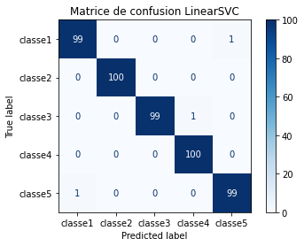

```python
# Train & Test
X_train1, y_train1 = df_app1.iloc[:,1:3],df_app1.iloc[:,0]
X_test1, y_test1 = df_dec1.iloc[:,1:3],df_dec1.iloc[:,0]

# Model
classifier = make_pipeline(StandardScaler(), LinearSVC(random_state=0, tol=1e-5))

classifier = classifier.fit(X_train1, y_train1)

# metrics
y_pred1 = classifier.predict(X_test1)
print("Performance:", accuracy_score(y_test1, y_pred1))
print("Précision:", precision_score(y_test1, y_pred1,
                                               average='micro'))
print("Rappel:", recall_score(y_test1, y_pred1,
                                               average='micro'))
print("F1-score:", f1_score(y_test1, y_pred1,
                                             average='micro'))

# Matrice de confusion
class_names = ['classe1', 'classe2', 'classe3', 'classe4', 'classe5']
disp = plot_confusion_matrix(classifier, X_test1, y_test1,
                                     display_labels=class_names,
                                     cmap=plt.cm.Blues,
                                     )
disp.ax_.set_title('Matrice de confusion LinearSVC')
plt.show()
```

### Commentaire :

Nous pouvons donc conclure que :

```
Le taux de bonne classification de notre modèle est de 99.4%

Notre modèle est précis à 99.4%

Ce qui nous est rappelé est de 99.4%

et enfin, notre f1_score est de 99.4%

Dans notre matrice de confusion alors que 497 observations ont correctement été prédites, 3 seulement ont été mal prédites ce qui s'avère être bon.
```

# 2) Utilisez la classe svm.SVC de scikit-learn :

En utilisant la documentation testez des SVM avec les paramètres suivants:

- Noyau: linéaire, C=1.0,
- Noyau: RBF, C=1.0, Gamma = 0.7,
- Noyau: Polynomial, C=1.0, degré: 3

A tester sur les jeux de données TP1 et TP2

```python
def SVM_Classification(Model, noyau, hyp, df_app, df_dec, model_summary, g=None):

    # Train & Test
    X_train, y_train = df_app.iloc[:,1:3],df_app.iloc[:,0]
    X_test, y_test = df_dec.iloc[:,1:3],df_dec.iloc[:,0]

    if(g==None):
        g=0.7

    # Model
    if(noyau=="linear"):
        classifier = make_pipeline(StandardScaler(), Model(kernel=noyau, C=hyp, random_state=0, tol=1e-5))
    elif(noyau=="rbf"):
        classifier = make_pipeline(StandardScaler(), Model(kernel=noyau, C=hyp, gamma=g, random_state=0, tol=1e-5))
    elif(noyau=="poly"):
        classifier = make_pipeline(StandardScaler(), Model(kernel=noyau, C=hyp, degree=3, random_state=0, tol=1e-5))
    else:
        classifier = make_pipeline(StandardScaler(), Model(kernel=noyau, C=hyp, random_state=0, tol=1e-5))

    classifier = classifier.fit(X_train, y_train)

    # metrics
    y_pred = classifier.predict(X_test)
    print("Performance:", accuracy_score(y_test, y_pred))
    print("Précision:", precision_score(y_test, y_pred,
                                               average='micro'))
    print("Rappel:", recall_score(y_test, y_pred,
                                               average='micro'))
    print("F1-score:", f1_score(y_test, y_pred,
                                               average='micro'))
    model_summary.append(dict(model="SVM "+str(noyau), accuracy_score=accuracy_score(y_test, y_pred)))

    # Matrice de confusion
    class_names = ['classe1', 'classe2', 'classe3', 'classe4', 'classe5']
    disp = plot_confusion_matrix(classifier, X_test, y_test,
                                     display_labels=class_names,
                                     cmap=plt.cm.Blues,
                                     )
    disp.ax_.set_title('Matrice de confusion '+str(noyau)+' model')
    plt.show()
```

### Jeu TP1

```python
model_summary_TP1 = []
```

```
Performance: 0.996
Précision: 0.996
Rappel: 0.996
F1-score: 0.996
```

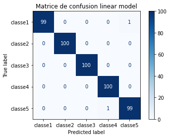

```python
SVM_Classification(SVC, "linear", 1.0, df_app1, df_dec1, model_summary_TP1)
```

```
Performance: 0.996
Précision: 0.996
Rappel: 0.996
F1-score: 0.996
```

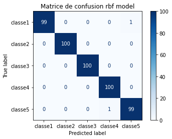

```python
SVM_Classification(SVC, "rbf", 1.0, df_app1, df_dec1, model_summary_TP1)
```

```
Performance: 0.986
Précision: 0.986
Rappel: 0.986
F1-score: 0.986
```

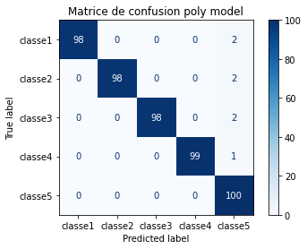

```python
SVM_Classification(SVC, "poly", 1.0, df_app1, df_dec1, model_summary_TP1)
```

petit bonus :

```
Performance: 0.996
Précision: 0.996
Rappel: 0.996
F1-score: 0.996
```

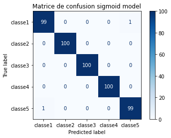

```python
SVM_Classification(SVC, "sigmoid", 1.0, df_app1, df_dec1, model_summary_TP1)
```

## Jeu TP2

```python
model_summary_TP2 = []
```

```
Performance: 0.952
Précision: 0.952
Rappel: 0.952
F1-score: 0.952
```

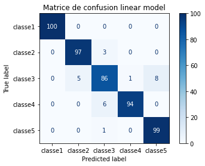

```python
SVM_Classification(SVC, "linear", 1.0, df_app2, df_dec2, model_summary_TP2)
```

```
Performance: 0.95
Précision: 0.95
Rappel: 0.95
F1-score: 0.9500000000000001
```

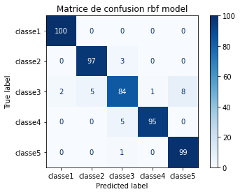

```python
SVM_Classification(SVC, "rbf", 1.0, df_app2, df_dec2, model_summary_TP2)
```

```
Performance: 0.932
Précision: 0.932
Rappel: 0.932
F1-score: 0.932
```

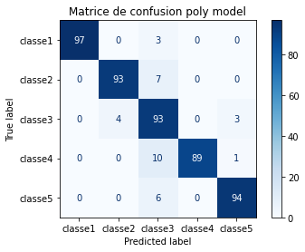

```python
SVM_Classification(SVC, "poly", 1.0, df_app2, df_dec2, model_summary_TP2)
```

petit bonus :

```
Performance: 0.93
Précision: 0.93
Rappel: 0.93
F1-score: 0.93
```

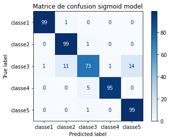

```python
SVM_Classification(SVC, "sigmoid", 1.0, df_app2, df_dec2, model_summary_TP2)
```

# 3) Sur les jeux de données TP1 et TP2, rechercher les meilleurs hyperparamètres pour les 3 noyaux.

```python
model_opti_summary = []
```

```python
def getHyperBestParam(X_train, y_train, X_test, y_test):
    # Set the parameters by cross-validation
    tuned_parameters = [{'kernel': ['rbf'], 'gamma': [1e-3, 1e-4],
                         'C': [1, 10, 100, 1000]},
                        {'kernel': ['linear'], 'C': [1, 10, 100, 1000]},
                        {'kernel': ['poly'], 'C': [1, 10, 100, 1000]}]

    scores = ['precision', 'recall']

    for score in scores:
        print("# Tuning hyper-parameters for %s" % score)
        print()

        clf = GridSearchCV(
            SVC(), tuned_parameters, scoring='%s_macro' % score
        )
        clf.fit(X_train, y_train)

        print("Best parameters set found on development set:")
        print()
        print(clf.best_params_)
        print()
        print("Grid scores on development set:")
        print()
        means = clf.cv_results_['mean_test_score']
        stds = clf.cv_results_['std_test_score']
        for mean, std, params in zip(means, stds, clf.cv_results_['params']):
            print("%0.3f (+/-%0.03f) for %r"
                  % (mean, std * 2, params))
        print()

        print("Detailed classification report:")
        print()
        print("The model is trained on the full development set.")
        print("The scores are computed on the full evaluation set.")
        print()
        y_true, y_pred = y_test, clf.predict(X_test)
        print(classification_report(y_true, y_pred))
        print()

    # Note the problem is too easy: the hyperparameter plateau is too flat and the
    # output model is the same for precision and recall with ties in quality.
```

## Recherche d'un bon hyper paramètre pour le jeu TP1

```python
getHyperBestParam(df_app1.iloc[:,1:3], df_app1.iloc[:,0], df_dec1.iloc[:,1:3], df_dec1.iloc[:,0])
```

```
# Tuning hyper-parameters for precision

Best parameters set found on development set:

{'C': 10, 'gamma': 0.001, 'kernel': 'rbf'}

Grid scores on development set:

0.996 (+/-0.009) for {'C': 1, 'gamma': 0.001, 'kernel': 'rbf'}
0.992 (+/-0.008) for {'C': 1, 'gamma': 0.0001, 'kernel': 'rbf'}
0.998 (+/-0.008) for {'C': 10, 'gamma': 0.001, 'kernel': 'rbf'}
0.996 (+/-0.009) for {'C': 10, 'gamma': 0.0001, 'kernel': 'rbf'}
0.998 (+/-0.008) for {'C': 100, 'gamma': 0.001, 'kernel': 'rbf'}
0.998 (+/-0.008) for {'C': 100, 'gamma': 0.0001, 'kernel': 'rbf'}
0.994 (+/-0.009) for {'C': 1000, 'gamma': 0.001, 'kernel': 'rbf'}
0.998 (+/-0.008) for {'C': 1000, 'gamma': 0.0001, 'kernel': 'rbf'}
0.998 (+/-0.008) for {'C': 1, 'kernel': 'linear'}
0.994 (+/-0.009) for {'C': 10, 'kernel': 'linear'}
0.994 (+/-0.009) for {'C': 100, 'kernel': 'linear'}
0.994 (+/-0.009) for {'C': 1000, 'kernel': 'linear'}
0.989 (+/-0.007) for {'C': 1, 'kernel': 'poly'}
0.991 (+/-0.012) for {'C': 10, 'kernel': 'poly'}
0.994 (+/-0.009) for {'C': 100, 'kernel': 'poly'}
0.994 (+/-0.009) for {'C': 1000, 'kernel': 'poly'}

Detailed classification report:

The model is trained on the full development set.
The scores are computed on the full evaluation set.

              precision    recall  f1-score   support

           1       0.99      0.99      0.99       100
           2       1.00      1.00      1.00       100
           3       1.00      1.00      1.00       100
           4       1.00      1.00      1.00       100
           5       0.99      0.99      0.99       100

    accuracy                           1.00       500
   macro avg       1.00      1.00      1.00       500
```

[output cut: 29 more lines]

```

The model is trained on the full development set.
The scores are computed on the full evaluation set.

              precision    recall  f1-score   support

           1       0.99      0.99      0.99       100
           2       1.00      1.00      1.00       100
           3       1.00      1.00      1.00       100
           4       1.00      1.00      1.00       100
           5       0.99      0.99      0.99       100

    accuracy                           1.00       500
   macro avg       1.00      1.00      1.00       500
weighted avg       1.00      1.00      1.00       500
```

### **pour TP1, le meilleur noyau est << RBF >>, le meilleur hyper paramètre associé est 10 et le bon gamma est 0.001**

```
Performance: 0.994
Précision: 0.994
Rappel: 0.994
F1-score: 0.994
```

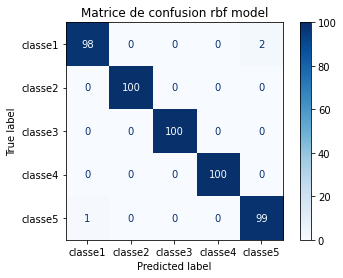

```python
SVM_Classification(SVC, "rbf", 10, df_app1, df_dec1, model_opti_summary, 0.001)
```

## Recherche d'un bon hyper paramètre pour le jeu TP2

```python
getHyperBestParam(df_app2.iloc[:,1:3], df_app2.iloc[:,0], df_dec2.iloc[:,1:3], df_dec2.iloc[:,0])
```

```
# Tuning hyper-parameters for precision

Best parameters set found on development set:

{'C': 1, 'gamma': 0.001, 'kernel': 'rbf'}

Grid scores on development set:

0.955 (+/-0.020) for {'C': 1, 'gamma': 0.001, 'kernel': 'rbf'}
0.895 (+/-0.057) for {'C': 1, 'gamma': 0.0001, 'kernel': 'rbf'}
0.947 (+/-0.024) for {'C': 10, 'gamma': 0.001, 'kernel': 'rbf'}
0.955 (+/-0.020) for {'C': 10, 'gamma': 0.0001, 'kernel': 'rbf'}
0.953 (+/-0.030) for {'C': 100, 'gamma': 0.001, 'kernel': 'rbf'}
0.947 (+/-0.024) for {'C': 100, 'gamma': 0.0001, 'kernel': 'rbf'}
0.949 (+/-0.031) for {'C': 1000, 'gamma': 0.001, 'kernel': 'rbf'}
0.953 (+/-0.030) for {'C': 1000, 'gamma': 0.0001, 'kernel': 'rbf'}
0.946 (+/-0.042) for {'C': 1, 'kernel': 'linear'}
0.946 (+/-0.036) for {'C': 10, 'kernel': 'linear'}
0.944 (+/-0.040) for {'C': 100, 'kernel': 'linear'}
0.946 (+/-0.036) for {'C': 1000, 'kernel': 'linear'}
0.936 (+/-0.040) for {'C': 1, 'kernel': 'poly'}
0.942 (+/-0.036) for {'C': 10, 'kernel': 'poly'}
0.942 (+/-0.042) for {'C': 100, 'kernel': 'poly'}
0.942 (+/-0.042) for {'C': 1000, 'kernel': 'poly'}

Detailed classification report:

The model is trained on the full development set.
The scores are computed on the full evaluation set.

              precision    recall  f1-score   support

           1       1.00      0.99      0.99       100
           2       0.95      0.99      0.97       100
           3       0.93      0.82      0.87       100
           4       0.98      0.97      0.97       100
           5       0.90      0.99      0.94       100

    accuracy                           0.95       500
   macro avg       0.95      0.95      0.95       500
```

[output cut: 29 more lines]

```

The model is trained on the full development set.
The scores are computed on the full evaluation set.

              precision    recall  f1-score   support

           1       0.99      1.00      1.00       100
           2       0.95      0.96      0.96       100
           3       0.90      0.85      0.88       100
           4       0.98      0.97      0.97       100
           5       0.93      0.98      0.96       100

    accuracy                           0.95       500
   macro avg       0.95      0.95      0.95       500
weighted avg       0.95      0.95      0.95       500
```

```
Performance: 0.95
Précision: 0.95
Rappel: 0.95
F1-score: 0.9500000000000001
```

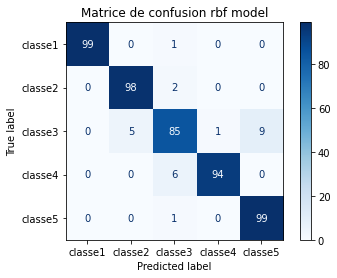

```python
SVM_Classification(SVC, "rbf", 100, df_app2, df_dec2, model_opti_summary, 0.001)
```

# 4) Bonus : Model summary

### 4.1) Résumé TP1

```python
df_sum_TP1 = pd.DataFrame(model_summary_TP1)
```

```python
df_sum_TP1
```

|  | model | accuracy_score |
| --- | --- | --- |
| 0 | SVM linear | 0.996 |
| 1 | SVM rbf | 0.996 |
| 2 | SVM poly | 0.986 |
| 3 | SVM sigmoid | 0.996 |

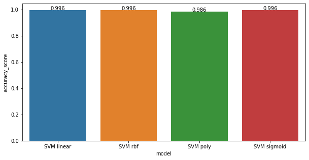

```python
figure = plt.figure(figsize=(10,5))
ax = sn.barplot(y='accuracy_score', x='model', data=df_sum_TP1)
# j'ajoute les valeurs
for index, row in df_sum_TP1.iterrows():
    ax.text(row.name,row.accuracy_score, round(row.accuracy_score,3), color='black', ha="center")

plt.show()
```

#### Commentaire :

Pour notre jeu TP1, sans cross validation, il s'avère que nous pouvons obtenir un bon résultat rien qu'avec un noyau Linéaire de plus ceci s'explique car les données que nos données sont dailleurs elles mêmes linéairement séparable.

### 4.2) Résumé TP2

```python
df_sum_TP2 = pd.DataFrame(model_summary_TP2)
```

```python
df_sum_TP2
```

|  | model | accuracy_score |
| --- | --- | --- |
| 0 | SVM linear | 0.952 |
| 1 | SVM rbf | 0.950 |
| 2 | SVM poly | 0.932 |
| 3 | SVM sigmoid | 0.930 |

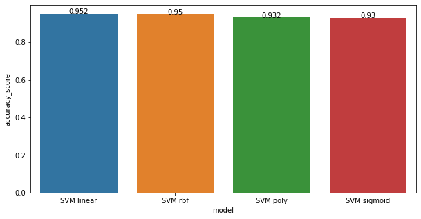

```python
figure = plt.figure(figsize=(10,5))
ax = sn.barplot(y='accuracy_score', x='model', data=df_sum_TP2)
# j'ajoute les valeurs
for index, row in df_sum_TP2.iterrows():
    ax.text(row.name,row.accuracy_score, round(row.accuracy_score,3), color='black', ha="center")

plt.show()
```

#### Commentaire :

Pour le jeu de données 2, sans Cross validation un noyau linéaire semble donner des résultats satisfaisant.

### 4.2) Résumé sur les meilleurs Hyper-paramètres selon les jeux de donénes 1 et 2

```python
df_sum = pd.DataFrame(model_opti_summary)
```

```python
df_sum.iloc[0,0]="Best model for TP1 : SVM_SVC(C:10,gamma:0.001)"
df_sum.iloc[1,0]="Best model for TP2 : SVM_SVC(C:100,gamma:0.001)"
```

```python
df_sum
```

|  | model | accuracy_score |
| --- | --- | --- |
| 0 | Best model for TP1 : SVM_SVC(C:10,gamma:0.001) | 0.994 |
| 1 | Best model for TP2 : SVM_SVC(C:100,gamma:0.001) | 0.950 |

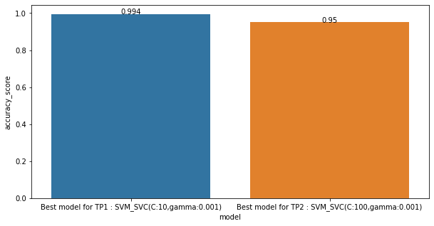

```python
figure = plt.figure(figsize=(10,5))
ax = sn.barplot(y='accuracy_score', x='model', data=df_sum)
# j'ajoute les valeurs
for index, row in df_sum.iterrows():
    ax.text(row.name,row.accuracy_score, round(row.accuracy_score,4), color='black', ha="center")

plt.show()
```

#### Commentaire :

Enfin on peut observer la performance de nos 2 modèles, avec leur meilleur hyper paramètre respectif.

Dans les 2 cas de figures : Un modèle SVM, type SVC avec comme hyper-paramètres C=10 (C=100) notre vitesse d'apprentissage et, Gamma=0.001, au départ nous étions parti d'un gamma = 0.7 mais lors de l'étape de recherche des régulateur optimal nous emmène à une réduction de ce dernier ce qui signifie que, afin de ne pas sur ajuster les données, on le réduit de tel sorte qu'on ait une frontère de décision beaucoup plus fine et donc, une courbe en cloche beaucoup plus élargit...bref, une zone d'influence pour élargit pour chaque observation.

#### Autre chose :

Le modèle LinearSVC semble aussi efficace qu'un modèle SVC.

# 3) Travail Pratique 4 : le perceptron à couche multiple dit réseaux de neuronnes :

### Réalisé par MULAPI TITA Ketsia

```python
import pandas as pd
```

```python
import numpy as np
```

```python
import matplotlib.pyplot as plt
```

## 1) Pretraitement

```python
def pretraitement(path):
    with open(path, 'r') as f:
        lines = f.readlines()
    classes=[]
    XList=[]
    YList=[]
    for line in lines:
        line = line.split(" ")
        classes.append(line[0])
        XList.append(line[1])
        YList.append(line[2].replace("\n",""))
    df = pd.DataFrame({"classes":classes,"X":XList,"Y":YList})
    df.info()
    return df
```

```python
df_app1 = pretraitement("data_tp1_app.txt")
```

```
<class 'pandas.core.frame.DataFrame'>
RangeIndex: 500 entries, 0 to 499
Data columns (total 3 columns):
 #   Column   Non-Null Count  Dtype
---  ------   --------------  -----
 0   classes  500 non-null    object
 1   X        500 non-null    object
 2   Y        500 non-null    object
dtypes: object(3)
memory usage: 11.8+ KB
```

```python
def getClasses(df):
    df.classes = df.classes.astype("int")
    df.X = df.X.astype("float")
    df.Y = df.Y.astype("float")
    return df
```

```python
df_app1 = getClasses(df_app1)
```

```python
def fromDFtoArray(df):
    return np.array(df)
```

Cette fonction nous permet d'ajouter un biais à notre jeux de données d'apprentissage ou, à notre n'importe quel dataset qui représenterai des valeurs devant passer apr une couche, afin qu'en entrée on puisse avoir 3 caractéristique (x,y,biais) avec biais=1 pour la couche d'entrée et donc, (x,y,...,biais) pour une couche quelconque.

```python
def getDfWithBiais(df):
    position = df.shape[1]
    df.insert(position,"Biais",1)
    return df
```

## 2) Fonction d'activation et de transfert : calcul de la sortie obtenue

```python
def noyau_activation(x):
    return 1/(1+np.exp(-x))
```

```python
def transfert_InputHidenOutput(df_data, df_Weight):
    assert df_data.shape[1] == df_Weight.shape[0]
    Entree = fromDFtoArray(df_data)
    Poids_EH = fromDFtoArray(df_Weight)
    return np.matmul(Entree,Poids_EH)
```

## 3) Détermination du nombre de neuronne en couche caché

- 2 neuronne d'entrée + 5 neuronnes de sorties, le tout divisé par 2

```python
nH = np.ceil((2 + 5) / 2)
nH
```

```
4.0
```

## 4) Le taux d'apprentissage

```python
µ = 0.1
```

## 5) Génération des poids, valeurs comprises entre -0.5 et 0.5

#### - Nombre de poids sans biais

- Nombre de Poids entre la couche d'entrée et la couche cachée

```python
NombredeWeight1 = 2*4
NombredeWeight1
```

```
8
```

2 neuronne en entrée et 4 dans la couche cachée

```python
NombredeWeight2 = 4*5
NombredeWeight2
```

```
20
```

4 neuronnes dans la couche cachée et 5 dans la couche de sortie

##### Nota Bene : Comprenons donc que, ici les biais ne sont pas pris en compte!

#### - Nombre de poids avec biais

- Fonction

```python
def WeightGeneration(n,connexion):
    #
    W = np.linspace(-0.5,0.5,num=n)
    #
    if connexion==1 :
        Weight_OF_EH = W.reshape((2, 4))
        BiaisW = np.linspace(-0.4,0.5,num=4)
        B = BiaisW.reshape((1,4))
    else :
        Weight_OF_EH = W.reshape((4, 5))
        BiaisW = np.linspace(-0.4,0.5,num=5)
        B = BiaisW.reshape((1,5))
    #
    TabOfWeight = np.concatenate((Weight_OF_EH,B),axis=0)
    #
    W_df = pd.DataFrame(TabOfWeight)
    print(W_df)
    return W_df
```

Nota Bene : si la Connexion=1, cela représente les premières connexions, c'ets à dire, celle entre la couche d'entrée et la cocuhe cahcée. Sinon ce sont les autres, dont notamment la 2e partie des connexions, celle entre la couche cachée et la couche de sortie.

- Pour 6 neuronnes dont 2 en entrée et 4 dans la couche caché on doit avoir 12 poids avec ceux associés aux biais y compris. on notera ce pendant qu'il ne doit pas exister de liaison entre le bais de la couche d'entrée et celui de sortie, cette laision est nulle, nous ferons alors en sorte que ce dernier ne soit pas considéré dans nos cacluls!

Algo : Et donc pour les générer on prendre les 8 connexions (2 * 4) entre les neuronnes + les 4 autres connexion qui nous emmène à 12 (ces 4 autres sont complétés dans la fonction WeightGeneration).

```python
W_E_H = WeightGeneration(8,1)
```

```
          0         1         2         3
0 -0.500000 -0.357143 -0.214286 -0.071429
1  0.071429  0.214286  0.357143  0.500000
2 -0.400000 -0.100000  0.200000  0.500000
```

Entre la couche d'entrée et la couche cachée on retrouve alors Nos 12 poids.

- Pour 9 neuronnes dont 4 dans la couche cachée et 5 dans la couche de sortie et 1 biais dans la couche cachée, on doit avoir 25 poids ! en raisons de 20 poids entre les neuronnes et 5 poids supplémentaires entre le bais et la couche de sortie.

```python
W_H_S = WeightGeneration(20,2)
```

```
          0         1         2         3         4
0 -0.500000 -0.447368 -0.394737 -0.342105 -0.289474
1 -0.236842 -0.184211 -0.131579 -0.078947 -0.026316
2  0.026316  0.078947  0.131579  0.184211  0.236842
3  0.289474  0.342105  0.394737  0.447368  0.500000
4 -0.400000 -0.175000  0.050000  0.275000  0.500000
```

##### Nota Bene : Comprenons donc que, ici les biais sont pris en compte, et c'est ce que nous allons utiliser. Le biais rappelons le, permet d'une manière ou d'une autre d'ajuster la froitère de décision qu'est l'hyperplan, d'où pour des donnés ou des cas pas facilement séparables au premier coup on sera dans l'obligation d'uiliser des bais afin de trouver le meilleur hyper plan.

# 🔽 Partie Chaînage avant

## 6) La couche d'entrée-cachée

```python
def InputLayer(df):
    return AddBiaisInDF(df)
```

```python
print("dimension Entrée-Cachée : "+str(W_E_H.shape)," et dimension données app : "+str(df_app1.shape))
```

```
dimension Entrée-Cachée : (3, 4)  et dimension données app : (500, 3)
```

la première colonne étant celle des classes, nous allons la conserver de coté

```python
df_classes_app = df_app1.iloc[:,0]
```

```python
df_classes_app
```

```
0      1
1      1
2      1
3      1
4      1
      ..
495    5
496    5
497    5
498    5
499    5
Name: classes, Length: 500, dtype: int64
```

Nous pouvons alors la récupérer dans un nouveau dataframe les coordonnées x et y puis ensuite ajouter à chaque point le biais=1.

- Récupération des X et des Y

```python
data_app = df_app1.iloc[:,1:3]
```

```python
data_app
```

|  | X | Y |
| --- | --- | --- |
| 0 | -6.315382 | 6.344938 |
| 1 | -4.943573 | 7.821684 |
| 2 | -8.920876 | 2.705258 |
| 3 | -5.661533 | 7.425065 |
| 4 | -5.918269 | 5.697313 |
| ... | ... | ... |
| 495 | -1.446325 | -0.422072 |
| 496 | 0.261599 | 0.479059 |
| 497 | -2.243814 | -0.673345 |
| 498 | -0.489892 | 0.282347 |
| 499 | 0.310185 | 0.024044 |

500 rows × 2 columns

- Ajout des biais

```python
data_app.shape
```

```
(500, 2)
```

```python
data_app = getDfWithBiais(data_app)
data_app
```

|  | X | Y | Biais |
| --- | --- | --- | --- |
| 0 | -6.315382 | 6.344938 | 1 |
| 1 | -4.943573 | 7.821684 | 1 |
| 2 | -8.920876 | 2.705258 | 1 |
| 3 | -5.661533 | 7.425065 | 1 |
| 4 | -5.918269 | 5.697313 | 1 |
| ... | ... | ... | ... |
| 495 | -1.446325 | -0.422072 | 1 |
| 496 | 0.261599 | 0.479059 | 1 |
| 497 | -2.243814 | -0.673345 | 1 |
| 498 | -0.489892 | 0.282347 | 1 |
| 499 | 0.310185 | 0.024044 | 1 |

500 rows × 3 columns

- On vérifie si les conditions de dimension pour la multiplication matricielle sont respécté par les 2 dataframe Data et Poids :

```python
data_app.shape[1] == W_E_H.shape[0]
```

```
True
```

- On obtient alors, la somme pondérée des valeurs en entrée par les poids.

```python
data = transfert_InputHidenOutput(data_app, W_E_H)
data
```

```
array([[ 3.21090086,  3.51512314,  3.81934543,  4.12356771],
       [ 2.63047821,  3.34163693,  4.05279564,  4.76395436],
       [ 4.25367071,  3.66572529,  3.07777986,  2.48983443],
       ...,
       [ 0.67381093,  0.55707393,  0.44033693,  0.32359993],
       [-0.13488636,  0.13546436,  0.40581507,  0.67616579],
       [-0.55337507, -0.20562807,  0.14211893,  0.48986593]])
```

chaque ligne ici est le résultat obtenu à partir d'un point (une entrée) et, chaque valeur dans une ligne est la somme pondérée obtenue sur un neuronne, il ne s'agit donc pas de la valeur obtenue après activation du neuronne, c'est ce que nosu faisons dans la suite.

- On utilise alors la fonction d'activation pour chaque neuronne afin de determiner les valeurs de la couche cachée

```python
def get_HiddenLayer(data):
    dim = data.shape
    # On active les neuronnes
    for i in range(dim[0]):
        for j in range(dim[1]):
            data[i,j]=noyau_activation(data[i,j])
    # On ajoute une colonne bias
    Biais = np.linspace(1,1,num=dim[0])
    Biais = Biais.reshape((dim[0],1))
    #
    data = np.concatenate((data,Biais),axis=1)
    # nous retournons les valeurs de chaque neuronnes, après activation, pour chaque point
    return data
```

```python
HiddenLayer = get_HiddenLayer(data)
HiddenLayer
```

```
array([[0.96124244, 0.97111502, 0.97852896, 0.98407117, 1.        ],
       [0.93279753, 0.96582991, 0.98292296, 0.99154037, 1.        ],
       [0.98598718, 0.97505268, 0.95596682, 0.9234261 , 1.        ],
       ...,
       [0.66235596, 0.63577523, 0.60833931, 0.58020133, 1.        ],
       [0.46632945, 0.5338144 , 0.60008399, 0.6628824 , 1.        ],
       [0.36508172, 0.44877336, 0.53547005, 0.62007485, 1.        ]])
```

Voici que nous avons pu obtenir notre couche cachée, passant à présent au calcul de l'erreur local, tout juste avant de passer à la deuxième partie de ce travail sur la couche cachée-sortie.

## 8) La couche cachée-sortie

```python
W_H_S.shape
```

```
(5, 5)
```

```python
HiddenLayer.shape
```

```
(500, 5)
```

```python
HiddenLayer.shape[1] == W_H_S.shape[0]
```

```
True
```

là encore nous sommes rassuré que le produit matriciel passera.

Donc on fait pareil, masi cette fois-ci avec nos deux dernières matrices de la cocuhe cachée et du poids respectivement : HiddenLayer, W_H_S

```python
def get_Predict_OutPutLayer(data):
    dim = data.shape
    # On active les neuronnes
    for i in range(dim[0]):
        for j in range(dim[1]):
            data[i,j]=noyau_activation(data[i,j])
    # nous retournons les classifications de chaque points, après activation pour chaque point
    return data
```

```python
data = transfert_InputHidenOutput(HiddenLayer, W_H_S)
predictions = get_Predict_OutPutLayer(data)
predictions
```

```
array([[0.31002366, 0.40853839, 0.51499222, 0.62010281, 0.71503852],
       [0.31383372, 0.41255579, 0.51885032, 0.62346554, 0.71771003],
       [0.30333591, 0.40027138, 0.50569814, 0.61062059, 0.70621046],
       ...,
       [0.33230142, 0.41534391, 0.50349008, 0.59141984, 0.67386436],
       [0.36542005, 0.44823497, 0.53402393, 0.61784644, 0.69519677],
       [0.37865932, 0.45844855, 0.54042722, 0.62027492, 0.69410215]])
```

On constate que l'on a pas les valeurs de sorties tel qu'on les attend par exemple, le premier point (la première ligne) est sensée nous donner 1 à la première valeur et 0 ailleurs. Et pourtant ici, on peut bien remarquer que nous avons d'autre valeurs. appliquons dans la suite le chaînage arrière en évaluant les erreurs.

# 🔽 Partie Chaînage arrière

## 7) Evaluations

## * CLassification

```python
def ConfigurationDesCLasses(sorties_attendues):
    n = len(sorties_attendues)
    outputValue = np.zeros((n,5))
    start = 0
    stop = 100
    for i in range(5):
        for j in range(start,stop):
            for k in range(5):
                if(sorties_attendues[j]-1==k):
                    outputValue[j,k] = 1
        start += 100
        stop += 100
    return outputValue
```

```python
realite = ConfigurationDesCLasses(df_classes_app)
realite
```

```
array([[1., 0., 0., 0., 0.],
       [1., 0., 0., 0., 0.],
       [1., 0., 0., 0., 0.],
       ...,
       [0., 0., 0., 0., 1.],
       [0., 0., 0., 0., 1.],
       [0., 0., 0., 0., 1.]])
```

## * taux de bonne performance

```python
def accuracy_evaluation(realite, predits):
    assert realite.shape == predits.shape
    dim = realite.shape
    bon = 0
    for i in range(dim[0]):
        for j in range(dim[1]):
            if (realite[i,j]==1 and realite[i,j] == predits[i,j]):
                bon += 1
    score = (bon * 100.0) / dim[0]
    print("le taux de performance est de : ",score," %")
    return score
```

### * Récupération des point mal classés

```python
def recup_point_mal_et_bien(realite, predits,dataset):
    assert realite.shape == predits.shape
    dim = realite.shape
    bad = pd.DataFrame()
    good = pd.DataFrame()
    for i in range(dim[0]):
        for j in range(dim[1]):
            if (realite[i,j]==1 and realite[i,j] != predits[i,j]) :
                bad.iloc[i,j]=dataset.iloc[i,j]
    for i in range(dim[0]):
        for j in range(dim[1]):
            if (realite[i,j]==1 and realite[i,j] == predits[i,j]) :
                good.iloc[i,j]=dataset.iloc[i,j]
    return bad, good
```

## * Les erreurs

### - Erreur en sortie

Formule :

( get_Predict_OutPutLayer - Output_desire) *( get_Predict_OutPutLayer* ( 1 - get_Predict_OutPutLayer ) )

on lire : ( sortie obtenue - sortie désirée ) *( sortie obtenue* (1 - sortie obtenue) )

```python
Output_Error = ( predictions - realite ) * ( predictions * ( 1 - predictions ) )
Output_Error
```

```
array([[-0.14759214,  0.09871708,  0.1286323 ,  0.14608091,  0.14569513],
       [-0.1477605 ,  0.09998434,  0.12952822,  0.14636244,  0.14540973],
       [-0.14722131,  0.09608683,  0.12640812,  0.14518304,  0.1465226 ],
       ...,
       [ 0.07373011,  0.10085935,  0.12586639,  0.14291212, -0.07167522],
       [ 0.08473661,  0.11085765,  0.13288778,  0.14588109, -0.06458726],
       [ 0.08908962,  0.11382062,  0.13422355,  0.1460958 , -0.06494956]])
```

### Et si on trichait ? Utilisons Une règle de décision : "fonction marche de Heaviside"

```
S(Nsortie) = 1 si Erreur_Nsortie < 0

S(Nsortie) = 0 sinon (Erreur_Nsortie >= 0)
```

```python
def heavside(OutputError):
    dim = OutputError.shape
    for i in range(dim[0]):
        for j in range(dim[1]):
            if(OutputError[i,j]<0):
                OutputError[i,j] = 1
            else :
                OutputError[i,j] = 0
        output = OutputError
    return output
```

```python
predits = heavside(Output_Error)
predits
```

```
array([[1., 0., 0., 0., 0.],
       [1., 0., 0., 0., 0.],
       [1., 0., 0., 0., 0.],
       ...,
       [0., 0., 0., 0., 1.],
       [0., 0., 0., 0., 1.],
       [0., 0., 0., 0., 1.]])
```

```python
for i in range(500):
        print(predits[i,:])
```

[output not shown]

[output cut: 445 more lines]

[output not shown]

```python
accuracy_evaluation(realite, predits)
```

```
('le taux de performance est de : ', 100.0, ' %')
```

Ceci me pousse à affirmer que les réseaux de neuronnes sur apprennent, en effet, autant nos données du dataset 1 sont très bien linéairement séparable, autant la recherche d'un hyperplan idéal est loins d'être fastidieux et donc, si pour chaque valeur obtenue en prédiction, on rejoins le score de 100% cela revient à dire qu'il n'ya pas eu d'erreurs, ce pendant, dans le cas contraire, on aurait fait une modification des poids, pour chaque points mal classés.

## * Modification des poids

```python
def Weight_update(MatricePoids, µ, Erreur, NeuronneValue):
    dim = MatricePoids.shape
    New_poids = np.zeros((dim[0],dim[1]))
    Err_V = Erreur*NeuronneValue # liste des points mal classé
    New_poids = []
    for i in range(Err_V.shape[0]): # pour chaque point mal classé
        for j in range(dim[0]):
            for k in range(dim[1]):
                MatricePoids[k,j] = MatricePoids[k,j]-(µ*Err_V[i,k])
        New_poids.append(MatricePoids)
    return MatricePoids
```

### - Erreur dans cachée

Formule :

( Somme( Output_Error *Poids_OutputLayer(i,k) )* HiddenLayer(i) * ( 1 - HiddenLayer(i) )

on lire : ( Erreurs_des_sorties_obtenues *Poids_Entre_CoucheCachee_Sortie )* ( NeuronneCache(i) * (1 - NeuronneCache(i) ) )

```python
Hidden_Error = ( Output_Error@W_H_S ) * ( HiddenLayer * ( 1 - HiddenLayer ) )
```

### - Erreur en entrée

Formule :

( Somme( Hidden_Error *Poids_HiddenLayer(i,k-1) )* InputLayer(i) * ( 1 - InputLayer(i) )

on lire : ( Erreurs_a_l_entree *Poids_Entre_CoucheCachee_Input )* ( NeuronneInput(i) * (1 - NeuronneInput(i) ) )

```python
 Hidden_Error_Without_Biais = Hidden_Error.iloc[:,:4]
```

```python
Input_Error = Hidden_Error_Without_Biais@W_E_H.T
```

### - Erreur Global

```python
# (1/2), sur 2 en raison de 2 entrées
Global_err = (1/2)*sum(sum(Output_Error - realite ))**(2)
```

## Dessinner un réseeau de neuronne :

### Pour cette fonction, Je me suis basée sur ce que propose *Brandon Amos, AI Engineer chez Facebook*

```python
import matplotlib.pyplot as plt

def dessiner_un_reseau(ax, left, right, bottom, top, layer_sizes):
    n_layers = len(layer_sizes)
    v_spacing = (top - bottom)/float(max(layer_sizes))
    h_spacing = (right - left)/float(len(layer_sizes) - 1)
    # Nodes
    for n, layer_size in enumerate(layer_sizes):
        layer_top = v_spacing*(layer_size - 1)/2. + (top + bottom)/2.
        for m in range(layer_size):
            circle = plt.Circle((n*h_spacing + left, layer_top - m*v_spacing), v_spacing/4.,
                                color='w', ec='k', zorder=4)
            ax.add_artist(circle)
    # Edges
    for n, (layer_size_a, layer_size_b) in enumerate(zip(layer_sizes[:-1], layer_sizes[1:])):
        layer_top_a = v_spacing*(layer_size_a - 1)/2. + (top + bottom)/2.
        layer_top_b = v_spacing*(layer_size_b - 1)/2. + (top + bottom)/2.
        for m in range(layer_size_a):
            for o in range(layer_size_b):
                line = plt.Line2D([n*h_spacing + left, (n + 1)*h_spacing + left],
                                  [layer_top_a - m*v_spacing, layer_top_b - o*v_spacing], c='k')
                ax.add_artist(line)
```

## # 🔽 Partie Algorihme MLP : Testons notre Réseau de neuronnes, en faisant appel aux fonctions prédéfiniement utilisé ainsi que les derniers poids et, obtenues à l'aide de nos données d'apprentissage et, qui nous ont permis d'obtenir une meilleure démarche

```python
def MLP(Data, PoidsIH, PoidsHS, µ):

    # ----- présentation de l'architecture ----- #
    entree = Data.shape[1]-1
    cachee = np.ceil((Data.shape[1]-1 + len(Data["classes"].unique()) / 2))
    sortie = len(Data["classes"].unique())
    print("1) Nous avons dans la couche d'entrée ",entree," neuronne.s, \n2) dans la couche cachée ",cachee," neuronne.s et, \n3)",sortie," neuronne.s dans la couche de sortie")


    # ----- pretraitement ----- #
    df_classes_app = df_app1.iloc[:,0]
    data_app = df_app1.iloc[:,1:df_app1.shape[1]]
    data_app = getDfWithBiais(data_app)

    # ----- chaînage_avant ----- #
    data = transfert_InputHidenOutput(data_app, PoidsIH)
    HiddenLayer = get_HiddenLayer(data)
    data = transfert_InputHidenOutput(HiddenLayer, PoidsHS)
    predictions = get_Predict_OutPutLayer(data)
    realite = ConfigurationDesCLasses(df_classes_app)
    err = (predictions - realite)*(predictions*(1-predictions))
    predits = heavside(err)
    print("\n")
    score = accuracy_evaluation(realite, predits)

    while(score!=100):

        # ----- chaînage_arriere : descente de gradient ----- #
        Hidden_Error = ( err@W_H_S ) * ( HiddenLayer * ( 1 - HiddenLayer ) )
        points_mal_classee, points_bien_classe = recup_point_mal_et_bien(realite, predits, data)
        New_Poids_HS = Weight_update(PoidsHS, µ, Hidden_Error, HiddenLayer)

        Hidden_Error_Without_Biais = Hidden_Error.iloc[:,:4]
        Input_Error = Hidden_Error_Without_Biais@PoidsIH.T
        New_Poids_IH = Weight_update(PoidsIH, µ, Input_Error, data)

        # on reprend l'algo avec avec les nouveaux poids et les points mal classés

        # ----- chaînage_avant ----- #
        data = transfert_InputHidenOutput(points_mal_classe, New_Poids_IH)
        HiddenLayer = get_HiddenLayer(data)
        data = transfert_InputHidenOutput(HiddenLayer, New_Poids_HS)
        predictions = get_Predict_OutPutLayer(data)

        # Concatenation des points bien et mal classé pour revérification du score
        data = np.concatenate((points_mal_classee, points_bien_classe),axis=0)
        err = (predictions - realite)*(predictions*(1-predictions))
        predits = heavside(err)
        score = accuracy_evaluation(realite, predits)

    print("\n Voici à quoi ressemble notre réseau (sans les biais visible !!! )")
    fig = plt.figure(figsize=(12, 12))
    ax = fig.gca()
    ax.axis('off')
    dessiner_un_reseau(ax, .1, .9, .1, .9, [int(entree), int(cachee), int(sortie)])
    fig.show()
```

# 🔽 Partie Test

```python
df_dec1 = pretraitement("data_tp1_dec.txt")
df_dec1 = getClasses(df_dec1)
```

```
<class 'pandas.core.frame.DataFrame'>
RangeIndex: 500 entries, 0 to 499
Data columns (total 3 columns):
 #   Column   Non-Null Count  Dtype
---  ------   --------------  -----
 0   classes  500 non-null    object
 1   X        500 non-null    object
 2   Y        500 non-null    object
dtypes: object(3)
memory usage: 11.8+ KB
```

[output not shown]

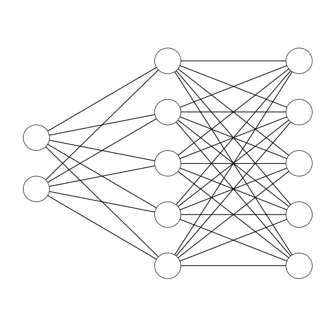

```python
MLP(df_dec1, W_E_H, W_H_S, µ)
```